# Ae. aegypti SNP chip - Segregation test using AaegL5 genome assembly

Luciano V Cosme

2023-12-18

# Validation of the *Aedes aegypti* chip using laboratory crosses

# Analytic approach

# Analysis code

## 1. Load libraries

```r
library(tidyverse)
library(here)
library(colorout)
library(flextable)
library(ggplot2)
library(scales)
library(reticulate)
library(extrafont)
library(stringr)
library(officer)
library(ggrepel)
library(readr)
library(pwr)
library(stats)
library(vcfR)
library(ggvenn)
library(RColorBrewer)
library(VariantAnnotation)
library(data.table)
library(dplyr)
```

## 2. Import the data

### 2.1 Data after mapping probes

We lift the annotation from the current genome, and the file8 has a chromosomal scale

```bash
head -n 5 output/segregation/file8.fam
```

```
## 16   16.01   16M 16F 2   -9
## 16   16.02   16M 16F 2   -9
## 16   16.03   16M 16F 2   -9
## 16   16.04   16M 16F 2   -9
## 16   16.05   16M 16F 2   -9
```

## 2. Check Mendel test with Plink

The command below set genotype missingness threshold to 20%, and remove variants with any error in any trio (–me 0 0 var-first) or arbitrary set allowed error rate (–me 0.1 0.02 var-first)

```bash
plink \
--allow-extra-chr \
--bfile output/segregation/file8 \
--mendel \
--me 0.1 0.02 var-first \
--me-exclude-one \
--out output/segregation/file9 \
--make-bed \
--geno 0.2 \
--keep-allele-order \
--write-snplist \
--silent;
head -n 100 output/segregation/file9.log
```

```
## PLINK v1.90b6.26 64-bit (2 Apr 2022)
## Options in effect:
##   --allow-extra-chr
##   --bfile output/segregation/file8
##   --geno 0.2
##   --keep-allele-order
##   --make-bed
##   --me 0.1 0.02 var-first
##   --me-exclude-one
##   --mendel
##   --out output/segregation/file9
##   --silent
##   --write-snplist
##
## Hostname: LucianoCosme.central.yale.internal
## Working directory: /Users/lucianocosme/Library/CloudStorage/Dropbox/popgen/brazil/aegypti
## Start time: Mon Dec 18 11:17:34 2023
##
## Random number seed: 1702916254
## 32768 MB RAM detected; reserving 16384 MB for main workspace.
## 18002 variants loaded from .bim file.
## 100 people (42 males, 58 females) loaded from .fam.
## Using 1 thread (no multithreaded calculations invoked).
## Before main variant filters, 6 founders and 94 nonfounders present.
## Calculating allele frequencies... done.
## Total genotyping rate is 0.964284.
## 607 variants removed due to missing genotype data (--geno).
## --me/--mendel: 92153 Mendel errors detected.
## Reports written to output/segregation/file9.mendel +
## output/segregation/file9.imendel + output/segregation/file9.fmendel +
## output/segregation/file9.lmendel .
## 5090 variants and 0 people excluded.
## 12305 variants and 100 people pass filters and QC.
## Note: No phenotypes present.
## List of variant IDs written to output/segregation/file9.snplist .
## --make-bed to output/segregation/file9.bed + output/segregation/file9.bim +
## output/segregation/file9.fam ... done.
##
## End time: Mon Dec 18 11:17:34 2023
```

The thresholds were arbitrary and we remove 5090 SNPs. We can use a statistical framework to test if the expected and observed allele frequencies are similar or different.

## 3. Find segregating SNPs

The PLINK –freqx command generates a .frqx file which contains allele frequencies for each SNP for each specific family.

### 3.1 Create bed files for each set of parents and offspring

We can subset our bed file to keep founders (parents) or non-founders (offspring). We will create vcf files for each data set.

#### 3.1.1 Parents

```bash
# Define the list of family IDs
families=("16" "25" "5")

# Iterate over each family
for fam_id in "${families[@]}"
do
    # Run Plink command for each family
    plink \
    --allow-extra-chr \
    --keep-fam <(echo -e "$fam_id") \
    --bfile output/segregation/file8 \
    --out output/segregation/parents_family_${fam_id} \
    --recode vcf \
    --geno 0 \
    --make-bed \
    --keep-allele-order \
    --silent \
    --filter-founders
done
```

#### 3.1.1 Offspring

```bash
# Define the list of family IDs
families=("16" "25" "5")

# Iterate over each family
for fam_id in "${families[@]}"
do
    # Run Plink command for each family
    plink \
    --allow-extra-chr \
    --keep-fam <(echo -e "$fam_id") \
    --bfile output/segregation/file8 \
    --out output/segregation/offspring_family_${fam_id} \
    --recode vcf \
    --keep-allele-order \
    --make-bed \
    --silent \
    --filter-nonfounders
done
```

### 3.2 Find the segregating SNPs using python

We can use vcf files that we created to estimate find the SNPs that are heterozygous in one parent.

```python
import os
import pysam
import sys
import contextlib

# Define a context manager to suppress stdout and stderr
@contextlib.contextmanager
def suppress_stdout_stderr():
    with open(os.devnull, 'w') as null_file:
        with contextlib.redirect_stdout(null_file), contextlib.redirect_stderr(null_file):
            yield

# Redirect standard output to the null device
sys.stdout = open(os.devnull, 'w')

vcf_files = [
    "output/segregation/parents_family_5.vcf",
    "output/segregation/parents_family_16.vcf",
    "output/segregation/parents_family_25.vcf"
]

for vcf_file in vcf_files:
    # Open the VCF file
    vcf = pysam.VariantFile(vcf_file, "r")

    # Set output file name
    output_file_name = vcf_file.replace(".vcf", "_segregating_SNPs_python.txt")

    # Open output file
    with open(output_file_name, "w") as output_file:
        # Iterate over each record
        for rec in vcf.fetch():
            # For each SNP
            if len(rec.alleles) == 2:  # Check if it's biallelic
                sample_1_gt = rec.samples.values()[0]['GT']  # Individual 1 genotype
                sample_2_gt = rec.samples.values()[1]['GT']  # Individual 2 genotype

                # Check that they are not homozygous for the same allele
                if not ((sample_1_gt == (0, 0) and sample_2_gt == (0, 0)) or (sample_1_gt == (1, 1) and sample_2_gt == (1, 1))):
                    output_file.write(f"{rec.id}\n")

# Restore standard output
sys.stdout = sys.__stdout__
```

### 3.3 Find the segregating SNPs using R

```r
vcf_files <- c(
  "output/segregation/parents_family_5.vcf",
  "output/segregation/parents_family_16.vcf",
  "output/segregation/parents_family_25.vcf"
)

for (vcf_file in vcf_files) {
  # Read the VCF file
  vcf <- readVcf(vcf_file)

  # Extract genotypes
  genotypes <- geno(vcf)$GT

  # Initialize the result vector
  result <- c()

  # Iterate over each record
  for (i in seq_len(nrow(genotypes))) {
    sample_1_gt <- genotypes[i, 1]
    sample_2_gt <- genotypes[i, 2]

    # Check that they are not homozygous for the same allele
    if (!(sample_1_gt == "0/0" &&
          sample_2_gt == "0/0") &&
        !(sample_1_gt == "1/1" && sample_2_gt == "1/1")) {
      result <- c(result, row.names(genotypes)[i])
    }
  }

  # Set output file name
  output_file_name <-
    gsub(".vcf", "_segregating_SNPs_R.txt", vcf_file)

  # Write the result to a file
  write.table(
    result,
    output_file_name,
    row.names = FALSE,
    col.names = FALSE,
    quote = FALSE
  )
}
```

Our goal: SNP can to be heterozygous in one sample if it is homozygous in the other sample SNP cannot be homozygous for the same allele in both samples (sample 1 = 0/0 and sample 2 = 0/0 or sample 1 = 1/1 and sample 2 = 2/2) SNP can be homozygous in both samples but for different allele (sample 1 = 1/1 and sample 2 = 0/0 or vice versa)

Clean memory and environment

```r
# python
py_run_string("import gc; gc.collect()")

# R
rm(list = ls())

# Clean up memory
gc()
```

```
##            used  (Mb) gc trigger  (Mb) limit (Mb) max used  (Mb)
## Ncells 10430148 557.1   17815777 951.5         NA 13267641 708.6
## Vcells 17982919 137.2   32418135 247.4      32768 26948441 205.7
```

### 3.4 Sanity check: count segregating SNPs for parents in each family

```bash
#ls output/segregation/parents_family_*_segregating_SNPs_*.txt

files=(
  output/segregation/parents_family_*_segregating_SNPs_R.txt
  output/segregation/parents_family_*_segregating_SNPs_python.txt
)

echo "family code SNPs"
for file in "${files[@]}"; do
  line=$(wc -l "$file")
  snps=$(echo "$line" | awk '{print $1}')
  family=$(basename "$file" | cut -d "_" -f 3)
  code=$(basename "$file" | cut -d "_" -f 6 | cut -d "." -f 1)
  echo "$family $code $snps"
done
```

```
## family code SNPs
## 16 R 10920
## 25 R 10467
## 5 R 9855
## 16 python 10920
## 25 python 10467
## 5 python 9855
```

The code worked as we expected.

### 3.5 Create Venn diagram for one family

Now compare the files for one family and see if they match

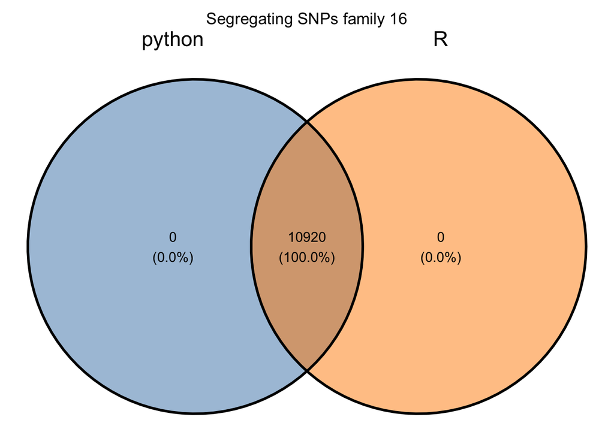

```r
# Read in the two files as vectors
family_16_segregating_SNPs_python <-
  read_table(
    "output/segregation/parents_family_16_segregating_SNPs_python.txt",
    col_names = FALSE
  )[[1]]

family_16_segregating_SNPs_R <-
  read_table(
    "output/segregation/parents_family_16_segregating_SNPs_R.txt",
    col_names = FALSE
  )[[1]]

# Calculate shared values
family_16_segregating_SNPs <-
  intersect(
    family_16_segregating_SNPs_python,
    family_16_segregating_SNPs_R
  )


# Create Venn diagram
venn_data <-
  list(
    "python" = family_16_segregating_SNPs_python,
    "R" = family_16_segregating_SNPs_R
  )
venn_plot <-
  ggvenn(
    venn_data,
    fill_color = c("steelblue", "darkorange"),
    show_percentage = TRUE
  )

# Add a title
venn_plot <-
  venn_plot +
  ggtitle("Segregating SNPs family 16") +
  theme(plot.title = element_text(hjust = .5))

# Display the Venn diagram
print(venn_plot)
```

```r
# Save Venn diagram to PDF
output_path <-
  here(
    "output",
    "segregation",
    "figures",
    "segregating_SNPs_parents_family_16.pdf"
  )
ggsave(
  output_path,
  venn_plot,
  height = 5,
  width = 5,
  dpi = 300
)
```

## 4. Calculate the expected and observed allele frequencies or counts

Plink has several utilities that we can use to find the expected and observed counts. I will go over some of them.

### 4.1 Estimate frequencies parents

```bash
# Define the list of family IDs
families=("16" "25" "5")

# Iterate over each family
for fam_id in "${families[@]}"
do
    # Run Plink command for each family
    plink \
    --allow-extra-chr \
    --bfile output/segregation/parents_family_${fam_id} \
    --out output/segregation/parents_freq_family_${fam_id} \
    --keep-allele-order \
    --extract output/segregation/parents_family_${fam_id}_segregating_SNPs_python.txt \
    --freqx \
    --silent
done
# use one of the flags below to replace --freq counts to get the 3 files I talk about in the text
# --freqx \ for counts
# --freq \ for MAF
```

### 4.2 Check the allele count of one family

From Plink documentation:

```
.frqx (genotype count report)

Produced by --freqx. Valid input for --read-freq.

A text file with a header line, and then one line per variant with the following ten fields:

CHR Chromosome code
SNP Variant identifier
A1  Allele 1 (usually minor)
A2  Allele 2 (usually major)
C(HOM A1)   A1 homozygote count
C(HET)  Heterozygote count
C(HOM A2)   A2 homozygote count
C(HAP A1)   Haploid A1 count (includes male X chromosome)
C(HAP A2)   Haploid A2 count
C(MISSING)  Missing genotype count
```

```bash
head output/segregation/parents_freq_family_16.frqx
```

```
## CHR  SNP A1  A2  C(HOM A1)   C(HET)  C(HOM A2)   C(HAP A1)   C(HAP A2)   C(MISSING)
## 1    AX-93255723 G   A   0   1   1   0   0   0
## 1    AX-93255722 A   T   0   1   1   0   0   0
## 1    AX-93255714 C   T   0   1   1   0   0   0
## 1    AX-93255713 G   A   0   1   1   0   0   0
## 1    AX-93255712 C   T   0   1   1   0   0   0
## 1    AX-93255711 G   A   1   0   1   0   0   0
## 1    AX-93255710 A   G   0   1   1   0   0   0
## 1    AX-93255704 G   A   0   1   1   0   0   0
## 1    AX-93255702 C   A   1   0   1   0   0   0
```

### 4.3 Check the minor allele allele count of one family

From Plink documentation:

```
.frq (basic allele frequency report)
Produced by --freq. Valid input for --read-freq.

A text file with a header line, and then one line per variant with the following six fields:

CHR Chromosome code
SNP Variant identifier
A1  Allele 1 (usually minor)
A2  Allele 2 (usually major)
MAF Allele 1 frequency
NCHROBS Number of allele observations
```

```bash
head output/segregation/parents_freq_family_16.frq
```

```
##  CHR           SNP   A1   A2          MAF  NCHROBS
##    1   AX-93255723    G    A         0.25        4
##    1   AX-93255722    A    T         0.25        4
##    1   AX-93255714    C    T         0.25        4
##    1   AX-93255713    G    A         0.25        4
##    1   AX-93255712    C    T         0.25        4
##    1   AX-93255711    G    A          0.5        4
##    1   AX-93255710    A    G         0.25        4
##    1   AX-93255704    G    A         0.25        4
##    1   AX-93255702    C    A          0.5        4
```

### 4.4 Check the counts of each allele

From Plink documentation:

```
.frq.count (basic allele count report)
Produced by "--freq counts". Valid input for --read-freq.

A text file with a header line, and then one line per variant with the following seven fields:

CHR Chromosome code
SNP Variant identifier
A1  Allele 1 (usually minor)
A2  Allele 2 (usually major)
C1  Allele 1 count
C2  Allele 2 count
G0  Missing genotype count (so C1 + C2 + 2 * G0 is constant on autosomal variants)
```

```bash
head output/segregation/parents_freq_family_16.frq.counts
```

```
##  CHR           SNP   A1   A2     C1     C2     G0
##    1   AX-93255723    G    A      1      3      0
##    1   AX-93255722    A    T      1      3      0
##    1   AX-93255714    C    T      1      3      0
##    1   AX-93255713    G    A      1      3      0
##    1   AX-93255712    C    T      1      3      0
##    1   AX-93255711    G    A      2      2      0
##    1   AX-93255710    A    G      1      3      0
##    1   AX-93255704    G    A      1      3      0
##    1   AX-93255702    C    A      2      2      0
```

### 4.5 Estimate frequencies for offspring

We can use the flang –freq counts to get the counts for each allele for all SNPs. It will also create the “NCHROBS” or “Number of allele observations”. Then we can use the “NCHROBS” value for each SNP, to calculate the expected counts for each parental allele.

```bash
# Define the list of family IDs
families=("16" "25" "5")

# Iterate over each family
for fam_id in "${families[@]}"
do
    # Run Plink command for each family
    plink \
    --allow-extra-chr \
    --bfile output/segregation/offspring_family_${fam_id} \
    --out output/segregation/offspring_freq_family_${fam_id} \
    --keep-allele-order \
    --extract output/segregation/parents_family_${fam_id}_segregating_SNPs_python.txt \
    --freqx \
    --nonfounders \
    --silent
done

# change the flags to get all frequencies
```

I run all the three flags and the output is below:

Allele count of one family

```bash
head output/segregation/offspring_freq_family_16.frqx
```

```
## CHR  SNP A1  A2  C(HOM A1)   C(HET)  C(HOM A2)   C(HAP A1)   C(HAP A2)   C(MISSING)
## 1    AX-93255723 G   A   1   20  10  0   0   0
## 1    AX-93255722 A   T   0   21  10  0   0   0
## 1    AX-93255714 C   T   0   19  10  0   0   2
## 1    AX-93255713 G   A   0   10  21  0   0   0
## 1    AX-93255712 C   T   0   21  10  0   0   0
## 1    AX-93255711 G   A   10  20  0   0   0   1
## 1    AX-93255710 A   G   0   10  21  0   0   0
## 1    AX-93255704 G   A   0   21  10  0   0   0
## 1    AX-93255702 C   A   0   10  21  0   0   0
```

Minor allele allele count of one family

```bash
head output/segregation/offspring_freq_family_16.frq
```

```
##  CHR           SNP   A1   A2          MAF  NCHROBS
##    1   AX-93255723    G    A       0.3548       62
##    1   AX-93255722    A    T       0.3387       62
##    1   AX-93255714    C    T       0.3276       58
##    1   AX-93255713    G    A       0.1613       62
##    1   AX-93255712    C    T       0.3387       62
##    1   AX-93255711    G    A       0.6667       60
##    1   AX-93255710    A    G       0.1613       62
##    1   AX-93255704    G    A       0.3387       62
##    1   AX-93255702    C    A       0.1613       62
```

Counts of each allele

```bash
head output/segregation/offspring_freq_family_16.frq.counts
```

```
##  CHR           SNP   A1   A2     C1     C2     G0
##    1   AX-93255723    G    A     22     40      0
##    1   AX-93255722    A    T     21     41      0
##    1   AX-93255714    C    T     19     39      2
##    1   AX-93255713    G    A     10     52      0
##    1   AX-93255712    C    T     21     41      0
##    1   AX-93255711    G    A     40     20      1
##    1   AX-93255710    A    G     10     52      0
##    1   AX-93255704    G    A     21     41      0
##    1   AX-93255702    C    A     10     52      0
```

### 4.6 Clean the Plink output files to import into R

The code below will convert the .frq files into csv files. Plink put uneven number of tabs or spaces between the variables.

```bash
for file in output/segregation/*.frq
do
  awk '{$1=$1; OFS=","}1' "$file" > "${file%.frq}.clean.csv"
done
```

Check one file

```bash
head output/segregation/offspring_freq_family_25.clean.csv
```

```
## CHR,SNP,A1,A2,MAF,NCHROBS
## 1,AX-93255723,G,A,0.2903,62
## 1,AX-93255722,A,T,0.2903,62
## 1,AX-93255713,G,A,0.7097,62
## 1,AX-93255712,C,T,0.2903,62
## 1,AX-93255710,A,G,0.7097,62
## 1,AX-93255704,G,A,0.2759,58
## 1,AX-93255700,T,C,0.7097,62
## 1,AX-93255697,T,C,0.2903,62
## 1,AX-93257574,A,G,0.5,54
```

### 4.7 Import frequency and counts

Here is the summary of what the code below does:

1. **Define family names:** A list of family names to be analyzed is defined and stored in the family_names variable.
2. **Initialize storage lists:** Two empty lists, family_parents and family_offspring, are created to store parental and offspring data respectively for each family.
3. **Read and store data:** A for loop is implemented to iterate over the family names. For each family:
   - **File path construction:** File paths for the parent and offspring data are constructed using string concatenation with the paste0 function.
   - **Data read:** Parent and offspring data are read from the constructed file paths using the read.csv function, specifying column names and types.
   - **Data storage:** The read parental data is added to the family_parents list for further processing.
4. **Calculation and update of frequencies and counts:** Another for loop is started to iterate over the family names. For each family:
   - **Data retrieval:** Offspring’s NCHROBS data and the corresponding parental data are retrieved from the family_offspring and family_parents lists respectively.
   - **Calculate expected frequencies and counts:** Expected frequencies and counts based on Minor Allele Frequency (MAF) for the parental data are calculated using the mutate function, adding these as new columns to the parental data.
   - **Update parental data:** The parental data in the family_parents list is updated with the new calculated columns.
   - **Calculate observed frequencies and counts:** Observed frequencies and counts based on MAF for the offspring data are calculated using the mutate function, adding these as new columns to the offspring data.
   - **Update offspring data:** The family_offspring list is updated with these newly calculated columns.

In summary, the main purpose of this R script below is to process and calculate the expected and observed frequencies and counts of SNPs for multiple families.

```r
# Define the list of family names
family_names <-
  c("family_16", "family_5", "family_25")

# Create empty lists to store the data for each family
family_parents <- list()
family_offspring <- list()

# Read and process the data for each family
for (family_name in family_names) {
  # Parental and offspring data paths
  parent_file_path <-
    paste0(
      "output/segregation/parents_freq_",
      family_name,
      ".clean.csv"
    )
  offspring_file_path <-
    paste0(
      "output/segregation/offspring_freq_",
      family_name,
      ".clean.csv"
    )

  # Read the input files
  family_parent <-
    read.csv(
      parent_file_path,
      stringsAsFactors = FALSE,
      col.names = c("CHR", "SNP", "A1", "A2", "MAF", "NCHROBS"),
      colClasses = c(
        "character",
        "character",
        "character",
        "character",
        "numeric",
        "numeric"
      )
    )
  family_offspring[[family_name]] <-
    read.csv(
      offspring_file_path,
      stringsAsFactors = FALSE,
      col.names = c("CHR", "SNP", "A1", "A2", "MAF", "NCHROBS"),
      colClasses = c(
        "character",
        "character",
        "character",
        "character",
        "numeric",
        "numeric"
      )
    )

  # Add the processed parental data to the list
  family_parents[[family_name]] <- family_parent
}

# Iterate over each family to calculate the expected and observed frequencies and counts
for (family_name in family_names) {
  # Get the offspring NCHROBS for this family
  offspring_NCHROBS <- family_offspring[[family_name]]$NCHROBS

  # Get the parental data for this family
  parental_data <- family_parents[[family_name]]

  # Calculate the expected frequencies and counts based on MAF
  parental_data <- parental_data |>
    mutate(
      Expected_A1 = 1 - MAF,
      Expected_A2 = MAF,
      Expected_A1_count = Expected_A1 * offspring_NCHROBS,
      Expected_A2_count = Expected_A2 * offspring_NCHROBS
    )

  # Update the parental data
  family_parents[[family_name]] <- parental_data

  # Calculate the observed frequencies and counts
  family_offspring[[family_name]] <-
    family_offspring[[family_name]] |>
    mutate(
      Observed_A1 = 1 - MAF,
      Observed_A2 = MAF,
      Observed_A1_count = Observed_A1 * NCHROBS,
      Observed_A2_count = Observed_A2 * NCHROBS
    )
}
```

Check the output

```r
str(family_offspring)
```

```
## List of 3
##  $ family_16:'data.frame':   10920 obs. of  10 variables:
##   ..$ CHR              : chr [1:10920] "1" "1" "1" "1" ...
##   ..$ SNP              : chr [1:10920] "AX-93255723" "AX-93255722" "AX-93255714" "AX-93255713" ...
##   ..$ A1               : chr [1:10920] "G" "A" "C" "G" ...
##   ..$ A2               : chr [1:10920] "A" "T" "T" "A" ...
##   ..$ MAF              : num [1:10920] 0.355 0.339 0.328 0.161 0.339 ...
##   ..$ NCHROBS          : num [1:10920] 62 62 58 62 62 60 62 62 62 62 ...
##   ..$ Observed_A1      : num [1:10920] 0.645 0.661 0.672 0.839 0.661 ...
##   ..$ Observed_A2      : num [1:10920] 0.355 0.339 0.328 0.161 0.339 ...
##   ..$ Observed_A1_count: num [1:10920] 40 41 39 52 41 ...
##   ..$ Observed_A2_count: num [1:10920] 22 21 19 10 21 ...
##  $ family_5 :'data.frame':   9855 obs. of  10 variables:
##   ..$ CHR              : chr [1:9855] "1" "1" "1" "1" ...
##   ..$ SNP              : chr [1:9855] "AX-93255723" "AX-93255722" "AX-93255713" "AX-93255712" ...
##   ..$ A1               : chr [1:9855] "G" "A" "G" "C" ...
##   ..$ A2               : chr [1:9855] "A" "T" "A" "T" ...
##   ..$ MAF              : num [1:9855] 0.797 0.797 0.183 0.797 0.203 ...
##   ..$ NCHROBS          : num [1:9855] 64 64 60 64 64 64 64 64 64 62 ...
##   ..$ Observed_A1      : num [1:9855] 0.203 0.203 0.817 0.203 0.797 ...
##   ..$ Observed_A2      : num [1:9855] 0.797 0.797 0.183 0.797 0.203 ...
##   ..$ Observed_A1_count: num [1:9855] 13 13 49 13 51 ...
##   ..$ Observed_A2_count: num [1:9855] 51 51 11 51 13 ...
##  $ family_25:'data.frame':   10467 obs. of  10 variables:
##   ..$ CHR              : chr [1:10467] "1" "1" "1" "1" ...
##   ..$ SNP              : chr [1:10467] "AX-93255723" "AX-93255722" "AX-93255713" "AX-93255712" ...
##   ..$ A1               : chr [1:10467] "G" "A" "G" "C" ...
##   ..$ A2               : chr [1:10467] "A" "T" "A" "T" ...
##   ..$ MAF              : num [1:10467] 0.29 0.29 0.71 0.29 0.71 ...
##   ..$ NCHROBS          : num [1:10467] 62 62 62 62 62 58 62 62 54 62 ...
##   ..$ Observed_A1      : num [1:10467] 0.71 0.71 0.29 0.71 0.29 ...
##   ..$ Observed_A2      : num [1:10467] 0.29 0.29 0.71 0.29 0.71 ...
##   ..$ Observed_A1_count: num [1:10467] 44 44 18 44 18 ...
##   ..$ Observed_A2_count: num [1:10467] 18 18 44 18 44 ...
```

```r
str(family_parents)
```

```
## List of 3
##  $ family_16:'data.frame':   10920 obs. of  10 variables:
##   ..$ CHR              : chr [1:10920] "1" "1" "1" "1" ...
##   ..$ SNP              : chr [1:10920] "AX-93255723" "AX-93255722" "AX-93255714" "AX-93255713" ...
##   ..$ A1               : chr [1:10920] "G" "A" "C" "G" ...
##   ..$ A2               : chr [1:10920] "A" "T" "T" "A" ...
##   ..$ MAF              : num [1:10920] 0.25 0.25 0.25 0.25 0.25 0.5 0.25 0.25 0.5 0.25 ...
##   ..$ NCHROBS          : num [1:10920] 4 4 4 4 4 4 4 4 4 4 ...
##   ..$ Expected_A1      : num [1:10920] 0.75 0.75 0.75 0.75 0.75 0.5 0.75 0.75 0.5 0.75 ...
##   ..$ Expected_A2      : num [1:10920] 0.25 0.25 0.25 0.25 0.25 0.5 0.25 0.25 0.5 0.25 ...
##   ..$ Expected_A1_count: num [1:10920] 46.5 46.5 43.5 46.5 46.5 30 46.5 46.5 31 46.5 ...
##   ..$ Expected_A2_count: num [1:10920] 15.5 15.5 14.5 15.5 15.5 30 15.5 15.5 31 15.5 ...
##  $ family_5 :'data.frame':   9855 obs. of  10 variables:
##   ..$ CHR              : chr [1:9855] "1" "1" "1" "1" ...
##   ..$ SNP              : chr [1:9855] "AX-93255723" "AX-93255722" "AX-93255713" "AX-93255712" ...
##   ..$ A1               : chr [1:9855] "G" "A" "G" "C" ...
##   ..$ A2               : chr [1:9855] "A" "T" "A" "T" ...
##   ..$ MAF              : num [1:9855] 0.75 0.75 0.25 0.75 0.25 0.5 0.25 0.25 0.5 0.25 ...
##   ..$ NCHROBS          : num [1:9855] 4 4 4 4 4 4 4 4 4 4 ...
##   ..$ Expected_A1      : num [1:9855] 0.25 0.25 0.75 0.25 0.75 0.5 0.75 0.75 0.5 0.75 ...
##   ..$ Expected_A2      : num [1:9855] 0.75 0.75 0.25 0.75 0.25 0.5 0.25 0.25 0.5 0.25 ...
##   ..$ Expected_A1_count: num [1:9855] 16 16 45 16 48 32 48 48 32 46.5 ...
##   ..$ Expected_A2_count: num [1:9855] 48 48 15 48 16 32 16 16 32 15.5 ...
##  $ family_25:'data.frame':   10467 obs. of  10 variables:
##   ..$ CHR              : chr [1:10467] "1" "1" "1" "1" ...
##   ..$ SNP              : chr [1:10467] "AX-93255723" "AX-93255722" "AX-93255713" "AX-93255712" ...
##   ..$ A1               : chr [1:10467] "G" "A" "G" "C" ...
##   ..$ A2               : chr [1:10467] "A" "T" "A" "T" ...
##   ..$ MAF              : num [1:10467] 0.25 0.25 0.75 0.25 0.75 0.25 0.75 0.25 0.5 0.5 ...
##   ..$ NCHROBS          : num [1:10467] 4 4 4 4 4 4 4 4 4 4 ...
##   ..$ Expected_A1      : num [1:10467] 0.75 0.75 0.25 0.75 0.25 0.75 0.25 0.75 0.5 0.5 ...
##   ..$ Expected_A2      : num [1:10467] 0.25 0.25 0.75 0.25 0.75 0.25 0.75 0.25 0.5 0.5 ...
##   ..$ Expected_A1_count: num [1:10467] 46.5 46.5 15.5 46.5 15.5 43.5 15.5 46.5 27 31 ...
##   ..$ Expected_A2_count: num [1:10467] 15.5 15.5 46.5 15.5 46.5 14.5 46.5 15.5 27 31 ...
```

Here are a few possibilities to consider if our observed frequencies are showing a wider range of values than expected:

**1. Sample Size:** - If our sample sizes are small, this could result in greater variation in the observed frequencies due to the inherent randomness in sampling.

**2. Sampling Bias:** - If the samples are not random, or if certain genotypes are more likely to be sampled than others, this could skew the observed frequencies.

**3. Genetic Drift:** - This is a random change in allele frequencies that occurs in small populations. Over time, it can lead to large changes in allele frequencies, especially if the population size is small.

**4. Genetic Linkage:** - If the SNPs are close to each other on a chromosome, they might be inherited together more often than would be expected by chance, leading to non-random associations between alleles.

**5. Non-random Mating:** - If mating is not random within the population, this could also skew the observed frequencies.

## 5. Data Visualization

We can prepare the data for plotting with the code below. In summary, the code does:

**1. Prepare tibbles for storing results:** - The “result_df_all” and “result_df_shared” tibbles are initialized as empty data structures to store the results.

**2. Define list names:** - A vector “list_names” is defined to store the names of the lists (e.g., family names) to be analyzed.

**3. Define intervals and labels:** - The “intervals” vector is defined as a sequence of values from 0 to 1 with a step of 0.1. - The “interval_labels” vector is defined to store the labels for each interval.

**4. Initialize epsilon value:** - The epsilon value is set as a small value to avoid exact bin border values.

**5. Retrieve SNP lists from each family:** - SNP lists from both parents and offspring are obtained for each family using the “lapply” function and stored in “all_offspring_snps” and “all_parents_snps” respectively.

**6. Find shared SNPs among families:** - The Reduce function is used to find the SNPs that are common to all families by taking the intersection of all offspring and parent SNP lists.

**7. Loop over list names:** - A loop is implemented to iterate over each family in the “list_names” vector.

**8. Offspring processing for all SNPs:** - Offspring data is processed for all SNPs in the current family: - Observed allele frequencies are binned into intervals using the “cut” function. - The data is transformed to a longer format using “pivot_longer”. - Grouping and summarization are performed based on family, type, variable, and interval using “group_by” and “summarize”. - The processed data is added to “tmp_offspring_all”.

**9. Parents processing for all SNPs:** - Parental data is processed for all SNPs in the current family following a similar process as in step 8.

**10. Combine all SNPs for analysis:** - The processed offspring and parental data for all SNPs in the current family are combined and added to “result_df_all”.

**11. Offspring processing for shared SNPs:** - Offspring data is processed for shared SNPs among families (common SNPs): - Filtering is applied to select only the shared SNPs. - Observed allele frequencies are binned into intervals using the “cut” function. - The data is transformed to a longer format using “pivot_longer”. - Grouping and summarization are performed based on family, type, variable, and interval using “group_by” and “summarize”. - The processed data is added to “tmp_offspring_shared”.

**12. Parents processing for shared SNPs:** - Parental data is processed for shared SNPs among families (common SNPs) following a similar process as in step 11.

**13. Combine shared SNPs for analysis:** - The processed offspring and parental data for shared SNPs in the current family are combined and added to “result_df_shared”.

**14. Add a new variable for faceting:** - A new variable “Family_Type” is created by combining family and type information in “result_df_all” and “result_df_shared”.

**15. Data wrangling steps before plotting:** - Variable names in “result_df_all” and “result_df_shared” are modified by removing the “Interval_” prefix.

**16. Set desired order for variable levels:** - The “desired_order” vector is defined to specify the desired order of variable levels. - Variable columns in “result_df_all” and “result_df_shared” are converted to factors with the desired order using the “factor” function.

```r
# Prepare two empty tibbles to store the results
result_df_all <- tibble()
result_df_shared <- tibble()

# List names
list_names <-
  c(
    "family_16", "family_5", "family_25"
  )

# Define intervals and labels
intervals <-
  seq(
    0, 1, 0.1
  )
interval_labels <-
  c(
    "0 ~ 0.1",
    "0.1 ~ 0.2",
    "0.2 ~ 0.3",
    "0.3 ~ 0.4",
    "0.4 ~ 0.5",
    "0.5 ~ 0.6",
    "0.6 ~ 0.7",
    "0.7 ~ 0.8",
    "0.8 ~ 0.9",
    "0.9 ~ 1"
  )

# Initialize a small epsilon value (we add this tiny tiny number to our values, so when we bin the data, we will not have values at the exact bin border)
epsilon <-
  .Machine$double.eps^0.5

# Get the SNP lists from each family in both parents and offspring
all_offspring_snps <-
  lapply(
    family_offspring, function(df) {
      df$SNP
    }
  )

all_parents_snps <- lapply(
  family_parents, function(df) {
    df$SNP
  }
)

# Find SNPs that are common to all families
shared_snps <-
  Reduce(
    intersect,
    c(
      all_offspring_snps, all_parents_snps
    )
  )

# Loop over both lists
for (i in seq_along(list_names)) {
  # Offspring
  tmp_offspring <- family_offspring[[i]]

  # Parents
  tmp_parents <- family_parents[[i]]

  # Offspring processing for all SNPs
  tmp_offspring_all <- tmp_offspring |>
    mutate(
      Interval_Observed_A1 = cut(
        Observed_A1,
        breaks = intervals + epsilon,
        labels = interval_labels
      ),
      Interval_Observed_A2 = cut(
        Observed_A2,
        breaks = intervals + epsilon,
        labels = interval_labels
      )
    ) |>
    pivot_longer(
      cols = starts_with("Interval"),
      names_to = "Variable",
      values_to = "Interval"
    ) |>
    group_by(
      Family = list_names[i],
      Type = "Offspring",
      Variable,
      Interval
    ) |>
    summarize(
      Count = n(), .groups = "drop"
    ) |>
    ungroup()

  # Parents processing for all SNPs
  tmp_parents_all <-
    tmp_parents |>
    mutate(
      Interval_Expected_A1 = cut(
        Expected_A1,
        breaks = intervals + epsilon,
        labels = interval_labels
      ),
      Interval_Expected_A2 = cut(
        Expected_A2,
        breaks = intervals + epsilon,
        labels = interval_labels
      )
    ) |>
    pivot_longer(
      cols = starts_with("Interval"),
      names_to = "Variable",
      values_to = "Interval"
    ) |>
    group_by(
      Family = list_names[i],
      Type = "Parents",
      Variable,
      Interval
    ) |>
    summarize(
      Count = n(), .groups = "drop"
    ) |>
    ungroup()

  # Combine all SNPs
  result_df_all <-
    bind_rows(
      result_df_all,
      tmp_offspring_all,
      tmp_parents_all
    )

  # Offspring processing for shared SNPs
  tmp_offspring_shared <-
    tmp_offspring |>
    filter(
      SNP %in% shared_snps
    ) |>
    mutate(
      Interval_Observed_A1 = cut(
        Observed_A1,
        breaks = intervals + epsilon,
        labels = interval_labels
      ),
      Interval_Observed_A2 = cut(
        Observed_A2,
        breaks = intervals + epsilon,
        labels = interval_labels
      )
    ) |>
    pivot_longer(
      cols = starts_with("Interval"),
      names_to = "Variable",
      values_to = "Interval"
    ) |>
    group_by(
      Family = list_names[i],
      Type = "Offspring",
      Variable,
      Interval
    ) |>
    summarize(
      Count = n(), .groups = "drop"
    ) |>
    ungroup()

  # Parents processing for shared SNPs
  tmp_parents_shared <-
    tmp_parents |>
    filter(
      SNP %in% shared_snps
    ) |>
    mutate(
      Interval_Expected_A1 = cut(
        Expected_A1,
        breaks = intervals + epsilon,
        labels = interval_labels
      ),
      Interval_Expected_A2 = cut(
        Expected_A2,
        breaks = intervals + epsilon,
        labels = interval_labels
      )
    ) |>
    pivot_longer(
      cols = starts_with("Interval"),
      names_to = "Variable",
      values_to = "Interval"
    ) |>
    group_by(
      Family = list_names[i],
      Type = "Parents",
      Variable,
      Interval
    ) |>
    summarize(
      Count = n(), .groups = "drop"
    ) |>
    ungroup()

  # Combine shared SNPs
  result_df_shared <-
    bind_rows(
      result_df_shared,
      tmp_offspring_shared,
      tmp_parents_shared
    )
}

# Add a new variable for faceting
result_df_all <-
  result_df_all |> mutate(
    Family_Type = paste(
      Family,
      Type,
      sep = "_"
    )
  )
result_df_shared <-
  result_df_shared |>
  mutate(
    Family_Type = paste(
      Family,
      Type,
      sep = "_"
    )
  )

# After data wrangling step before the plot
result_df_all$Variable <-
  str_remove(
    result_df_all$Variable,
    "Interval_"
  )
result_df_shared$Variable <-
  str_remove(
    result_df_shared$Variable,
    "Interval_"
  )

# Set desired order
desired_order <-
  c(
    "Expected_A1",
    "Observed_A1",
    "Expected_A2",
    "Observed_A2"
  )

# Convert Variable to a factor with desired levels
result_df_all$Variable <-
  factor(
    result_df_all$Variable,
    levels = desired_order
  )
result_df_shared$Variable <-
  factor(
    result_df_shared$Variable,
    levels = desired_order
  )
```

### 5.1 Get the unique total SNP count across all families that we can test

```r
# count of SNPs across all families
offspring_SNPs <-
  unlist(
    lapply(
      family_offspring, function(df) {
        df$SNP
      }
    )
  )
parent_SNPs <- unlist(lapply(family_parents, function(df) {
  df$SNP
}))

# Combine offspring and parents SNPs
all_SNPs <- c(offspring_SNPs, parent_SNPs)

# Get the number of unique SNPs
num_unique_SNPs <- length(unique(all_SNPs))

print(num_unique_SNPs)
```

```
## [1] 16843
```

### 5.2 Get the “shared” SNPs (genotyped in all 3 families)

```r
# Initialize shared_snps with the SNPs of the first family
shared_snps <-
  family_offspring[[1]]$SNP

# Loop over the rest of the lists
for (i in 2:length(list_names)) {
  # Get the intersection of shared_snps and the SNPs of the current family
  shared_snps <- intersect(shared_snps, family_offspring[[i]]$SNP)
}

# The length of shared_snps gives the total number of SNPs shared among all families
num_shared_snps <-
  length(shared_snps)

print(num_shared_snps)
```

```
## [1] 4286
```

### 5.3 “Shared” among at least two families

```r
# Combine SNPs from all families into a single vector
all_snps <-
  c(family_offspring[[1]]$SNP,
    family_offspring[[2]]$SNP,
    family_offspring[[3]]$SNP)

# Count the occurrence of each SNP
snp_counts <- table(all_snps)

# Get the SNPs that occur in at least two families
shared_snps <- names(snp_counts[snp_counts >= 2])

# The length of shared_snps gives the total number of SNPs shared among at least two families
num_shared_snps <- length(shared_snps)

print(num_shared_snps)
```

```
## [1] 10113
```

### 5.4 Plot allele counts

Now we can plot the data with the allele counts

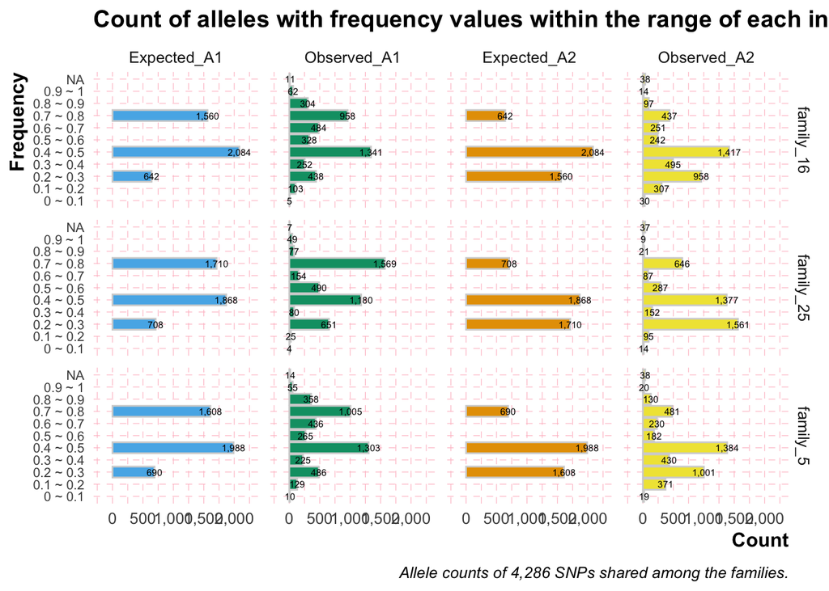

```r
# source function theme
source(
  here(
    "scripts", "analysis", "my_theme2.R"
  )
)

# create plot with the frequencies - use result_df_all for all SNPs or result_df_shared for the shared SNPs among the three families
ggplot(
  result_df_shared,
  aes(
    x = Interval,
    y = Count,
    fill = Variable
  )
) +
  geom_bar(
    stat = "identity",
    color = "lightgray",
    width = 0.9,
    position = "dodge"
  ) +
  geom_text(
    aes(
      label = scales::comma(Count)
    ),
    size = 2,
    position = position_dodge(width = 0.9)
  ) +
  facet_grid(
    Family ~ Variable,
    scales = "free_y", space = "free"
  ) +
  labs(
    x = "Frequency",
    y = "Count",
    title = "Count of alleles with frequency values within the range of each interval",
    caption = "Allele counts of 4,286 SNPs shared among the families."
  ) +
  scale_fill_manual(
    values = c(
      "Expected_A1" = "#56B4E9",
      "Expected_A2" = "#E69F00",
      "Observed_A1" = "#009E73",
      "Observed_A2" = "#F0E442"
    ),
    guide = "none"
  ) +
  scale_y_continuous(
    labels = scales::comma, expand = c(0.15, 0.15)
  ) +
  scale_x_discrete(
    drop = FALSE
  ) +
  my_theme() +
  theme(
    plot.caption = element_text(
      hjust = 1,
      margin = margin(t = 10),
      face = "italic"
    ),
    legend.position = "none",
    # Remove the legend
    panel.spacing = unit(0.5, "lines"),
    axis.text.y = element_text(size = 8),
    plot.title = element_text(face = "bold")
  ) +
  coord_flip()
```

```r
# save plot
ggsave(
  here(
    "output",
    "segregation",
    "figures",
    # "allele_frequencies_all_SNPS.pdf"
    "allele_frequencies_shared_SNPS.pdf"
  ),
  width = 8,
  height = 5,
  units = "in"
)
```

### 5.5 Pie plot of the frequencies

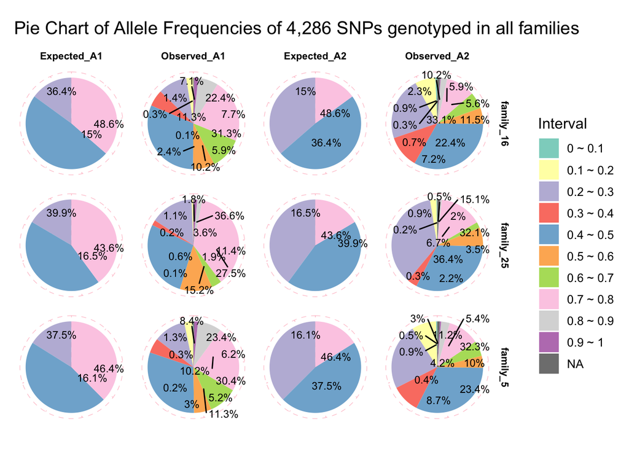

```r
# Calculate percentages for each pie
result_df_pie <-
  result_df_shared |>
  group_by(
    Family, Type, Variable, Interval
  ) |>
  summarise(
    count = sum(Count), .groups = "drop"
  ) |>
  group_by(
    Family, Type, Variable
  ) |>
  mutate(
    percentage = count / sum(count) * 100
  ) |>
  ungroup() |>
  group_by(
    Family, Type, Variable
  ) |>
  mutate(
    total_count = sum(count)
  ) |>
  mutate(
    proportional_count = count / total_count
  ) |>
  ungroup()

# Generate palette with as many colors as intervals
color_palette <-
  colorRampPalette(brewer.pal(11, "Set3"))(length(unique(result_df_pie$Interval)))

# Plot
ggplot(
  result_df_pie, aes(x = "", y = count, fill = Interval)
) +
  geom_bar(
    width = 1, stat = "identity"
  ) +
  geom_text_repel(
    aes(
      y = count / 2,
      label = paste0(
        round(percentage, 1),
        "%"
      )
    ),
    position = position_stack(vjust = 0.0),
    size = 3,
    max.overlaps = Inf,
    force = 10
  ) + # Increase max.overlaps and force
  coord_polar(
    "y",
    start = 0
  ) +
  facet_grid(
    Family ~ Variable
  ) +
  my_theme() +
  theme(
    axis.title.x = element_blank(),
    axis.title.y = element_blank(),
    panel.background = element_blank(),
    axis.text.x = element_blank(),
    axis.ticks = element_blank(),
    strip.text.x = element_text(
      size = 8,
      colour = "black",
      face = "bold"
    ),
    strip.text.y = element_text(
      size = 8,
      colour = "black",
      face = "bold"
    )
  ) +
  scale_fill_manual(
    values = color_palette
  ) +
  labs(
    title = "Pie Chart of Allele Frequencies of 4,286 SNPs genotyped in all families",
    fill = "Interval"
  )
```

```r
# Save the plot
ggsave(
  here(
    "output",
    "segregation",
    "figures",
    # "allele_frequency_pie_plots_all_SNPs.pdf"
    "allele_frequency_pie_plots_shared_SNPs.pdf"
  ),
  width = 8,
  height = 7,
  units = "in"
)
```

### 5.6 Check for NAs

We see that we have some missing genotype calls for some SNPs in the offspring. We can check how many we have with the code below.

```r
# Count NAs in each column of family_parents
cat("NAs in family_data_parents:")
```

```
## NAs in family_data_parents:
```

```r
print(colSums(sapply(family_parents, function(df) colSums(is.na(df)))))
```

```
## family_16  family_5 family_25
##         0         0         0
```

```r
# Count NAs in each column of family_offspring
cat("NAs in family_data_parents:")
```

```
## NAs in family_data_parents:
```

```r
print(colSums(sapply(family_offspring, function(df) colSums(is.na(df)))))
```

```
## family_16  family_5 family_25
##        30        15        35
```

## 6. Tidying the data for statistical comparisons

First we remove SNPs withing each family that are missing in the offspring

### 6.1 Remove NAs

```r
# Remove NA values from family_data_parents
family_parents_2 <- lapply(family_parents, function(df) {
  df |>
    drop_na(SNP, starts_with("Expected"))
})

# Remove NA values from family_data_offspring
family_offspring_2 <- lapply(family_offspring, function(df) {
  df |>
    drop_na(SNP, starts_with("Observed"))
})
```

Check if it worked

```r
# Count NAs in each column of family_parents
cat("NAs in family_data_parents:")
```

```
## NAs in family_data_parents:
```

```r
print(colSums(sapply(family_parents_2, function(df) colSums(is.na(df)))))
```

```
## family_16  family_5 family_25
##         0         0         0
```

```r
# Count NAs in each column of family_offspring
cat("NAs in family_data_parents:")
```

```
## NAs in family_data_parents:
```

```r
print(colSums(sapply(family_offspring_2, function(df) colSums(is.na(df)))))
```

```
## family_16  family_5 family_25
##         0         0         0
```

Check the output

```r
str(family_parents_2)
```

```
## List of 3
##  $ family_16:'data.frame':   10920 obs. of  10 variables:
##   ..$ CHR              : chr [1:10920] "1" "1" "1" "1" ...
##   ..$ SNP              : chr [1:10920] "AX-93255723" "AX-93255722" "AX-93255714" "AX-93255713" ...
##   ..$ A1               : chr [1:10920] "G" "A" "C" "G" ...
##   ..$ A2               : chr [1:10920] "A" "T" "T" "A" ...
##   ..$ MAF              : num [1:10920] 0.25 0.25 0.25 0.25 0.25 0.5 0.25 0.25 0.5 0.25 ...
##   ..$ NCHROBS          : num [1:10920] 4 4 4 4 4 4 4 4 4 4 ...
##   ..$ Expected_A1      : num [1:10920] 0.75 0.75 0.75 0.75 0.75 0.5 0.75 0.75 0.5 0.75 ...
##   ..$ Expected_A2      : num [1:10920] 0.25 0.25 0.25 0.25 0.25 0.5 0.25 0.25 0.5 0.25 ...
##   ..$ Expected_A1_count: num [1:10920] 46.5 46.5 43.5 46.5 46.5 30 46.5 46.5 31 46.5 ...
##   ..$ Expected_A2_count: num [1:10920] 15.5 15.5 14.5 15.5 15.5 30 15.5 15.5 31 15.5 ...
##  $ family_5 :'data.frame':   9855 obs. of  10 variables:
##   ..$ CHR              : chr [1:9855] "1" "1" "1" "1" ...
##   ..$ SNP              : chr [1:9855] "AX-93255723" "AX-93255722" "AX-93255713" "AX-93255712" ...
##   ..$ A1               : chr [1:9855] "G" "A" "G" "C" ...
##   ..$ A2               : chr [1:9855] "A" "T" "A" "T" ...
##   ..$ MAF              : num [1:9855] 0.75 0.75 0.25 0.75 0.25 0.5 0.25 0.25 0.5 0.25 ...
##   ..$ NCHROBS          : num [1:9855] 4 4 4 4 4 4 4 4 4 4 ...
##   ..$ Expected_A1      : num [1:9855] 0.25 0.25 0.75 0.25 0.75 0.5 0.75 0.75 0.5 0.75 ...
##   ..$ Expected_A2      : num [1:9855] 0.75 0.75 0.25 0.75 0.25 0.5 0.25 0.25 0.5 0.25 ...
##   ..$ Expected_A1_count: num [1:9855] 16 16 45 16 48 32 48 48 32 46.5 ...
##   ..$ Expected_A2_count: num [1:9855] 48 48 15 48 16 32 16 16 32 15.5 ...
##  $ family_25:'data.frame':   10467 obs. of  10 variables:
##   ..$ CHR              : chr [1:10467] "1" "1" "1" "1" ...
##   ..$ SNP              : chr [1:10467] "AX-93255723" "AX-93255722" "AX-93255713" "AX-93255712" ...
##   ..$ A1               : chr [1:10467] "G" "A" "G" "C" ...
##   ..$ A2               : chr [1:10467] "A" "T" "A" "T" ...
##   ..$ MAF              : num [1:10467] 0.25 0.25 0.75 0.25 0.75 0.25 0.75 0.25 0.5 0.5 ...
##   ..$ NCHROBS          : num [1:10467] 4 4 4 4 4 4 4 4 4 4 ...
##   ..$ Expected_A1      : num [1:10467] 0.75 0.75 0.25 0.75 0.25 0.75 0.25 0.75 0.5 0.5 ...
##   ..$ Expected_A2      : num [1:10467] 0.25 0.25 0.75 0.25 0.75 0.25 0.75 0.25 0.5 0.5 ...
##   ..$ Expected_A1_count: num [1:10467] 46.5 46.5 15.5 46.5 15.5 43.5 15.5 46.5 27 31 ...
##   ..$ Expected_A2_count: num [1:10467] 15.5 15.5 46.5 15.5 46.5 14.5 46.5 15.5 27 31 ...
```

```r
str(family_offspring_2)
```

```
## List of 3
##  $ family_16:'data.frame':   10914 obs. of  10 variables:
##   ..$ CHR              : chr [1:10914] "1" "1" "1" "1" ...
##   ..$ SNP              : chr [1:10914] "AX-93255723" "AX-93255722" "AX-93255714" "AX-93255713" ...
##   ..$ A1               : chr [1:10914] "G" "A" "C" "G" ...
##   ..$ A2               : chr [1:10914] "A" "T" "T" "A" ...
##   ..$ MAF              : num [1:10914] 0.355 0.339 0.328 0.161 0.339 ...
##   ..$ NCHROBS          : num [1:10914] 62 62 58 62 62 60 62 62 62 62 ...
##   ..$ Observed_A1      : num [1:10914] 0.645 0.661 0.672 0.839 0.661 ...
##   ..$ Observed_A2      : num [1:10914] 0.355 0.339 0.328 0.161 0.339 ...
##   ..$ Observed_A1_count: num [1:10914] 40 41 39 52 41 ...
##   ..$ Observed_A2_count: num [1:10914] 22 21 19 10 21 ...
##  $ family_5 :'data.frame':   9852 obs. of  10 variables:
##   ..$ CHR              : chr [1:9852] "1" "1" "1" "1" ...
##   ..$ SNP              : chr [1:9852] "AX-93255723" "AX-93255722" "AX-93255713" "AX-93255712" ...
##   ..$ A1               : chr [1:9852] "G" "A" "G" "C" ...
##   ..$ A2               : chr [1:9852] "A" "T" "A" "T" ...
##   ..$ MAF              : num [1:9852] 0.797 0.797 0.183 0.797 0.203 ...
##   ..$ NCHROBS          : num [1:9852] 64 64 60 64 64 64 64 64 64 62 ...
##   ..$ Observed_A1      : num [1:9852] 0.203 0.203 0.817 0.203 0.797 ...
##   ..$ Observed_A2      : num [1:9852] 0.797 0.797 0.183 0.797 0.203 ...
##   ..$ Observed_A1_count: num [1:9852] 13 13 49 13 51 ...
##   ..$ Observed_A2_count: num [1:9852] 51 51 11 51 13 ...
##  $ family_25:'data.frame':   10460 obs. of  10 variables:
##   ..$ CHR              : chr [1:10460] "1" "1" "1" "1" ...
##   ..$ SNP              : chr [1:10460] "AX-93255723" "AX-93255722" "AX-93255713" "AX-93255712" ...
##   ..$ A1               : chr [1:10460] "G" "A" "G" "C" ...
##   ..$ A2               : chr [1:10460] "A" "T" "A" "T" ...
##   ..$ MAF              : num [1:10460] 0.29 0.29 0.71 0.29 0.71 ...
##   ..$ NCHROBS          : num [1:10460] 62 62 62 62 62 58 62 62 54 62 ...
##   ..$ Observed_A1      : num [1:10460] 0.71 0.71 0.29 0.71 0.29 ...
##   ..$ Observed_A2      : num [1:10460] 0.29 0.29 0.71 0.29 0.71 ...
##   ..$ Observed_A1_count: num [1:10460] 44 44 18 44 18 ...
##   ..$ Observed_A2_count: num [1:10460] 18 18 44 18 44 ...
```

### 6.2 Sort by SNP id

```r
# Sort family_offspring_2 by SNP column
family_offspring_2 <- lapply(family_offspring_2, function(df) df[order(df$SNP), ])

# Sort family_parents_2 by SNP column
family_parents_2 <- lapply(family_parents_2, function(df) df[order(df$SNP), ])
```

## 7. Power simulation

We can simulate how much power we would have with different parameters. Summary of the code below: 1. **Define the range of significance levels, effect sizes, and sample sizes:** - The vector “significance_levels” contains different significance levels to be analyzed. - The vector “effect_sizes” contains different effect sizes to be analyzed. - The vector “sample_sizes” contains different sample sizes to be analyzed.

2. **Create an empty data frame to store the results:**
   - The data frame “df” is created to store the results of the power analysis.
3. **Perform power analysis for each combination of parameters:**
   - Two nested “for” loops are used to iterate over each combination of significance level and sample size.
   - For each combination, a data frame “df_comb” is created to store the results for that specific combination.
   - The columns “effect_size”, “significance_level”, “sample_size”, and “power” are initialized in “df_comb”.
4. **Perform power analysis for each effect size in the current combination:**
   - Another “for” loop is used to iterate over each effect size in the current combination.
   - For each effect size, the power analysis is performed using the “pwr.chisq.test” function.
   - The resulting power value is stored in the corresponding row of “df_comb”.
5. **Append the data frame for the current combination to the overall data frame:**
   - After performing the power analysis for all effect sizes in the current combination, “df_comb” is appended to the overall data frame “df” using the “rbind” function.

The code iterates over all combinations of significance levels, effect sizes, and sample sizes, and calculates the power for each combination using the “pwr.chisq.test” function. The results are stored in the data frame “df”, which will contain the effect size, significance level, sample size, and corresponding power for each combination.

```r
# Define the range of significance levels, effect sizes, and sample sizes
significance_levels <- c(0.001, 0.01, 0.05, 0.1)
effect_sizes <- c(0.01, 0.05, 0.5)
sample_sizes <- c(10, 20, 30, 40, 50, 60, 70) # we have 30 to 32 offspring per family.

# Create an empty data frame to store the results
df <- data.frame()

# Perform power analysis for each combination of parameters
for (significance_level in significance_levels) {
  for (sample_size in sample_sizes) {
    # Create a data frame for the current combination of significance level and sample size
    df_comb <- data.frame(
      effect_size = effect_sizes,
      significance_level = rep(significance_level, length(effect_sizes)),
      sample_size = rep(sample_size, length(effect_sizes)),
      power = rep(NA, length(effect_sizes))
    )

    # Perform power analysis for each effect size in the current combination
    for (i in seq_along(effect_sizes)) {
      effect_size <- effect_sizes[i]
      power <-
        pwr.chisq.test(
          w = effect_size,
          N = sample_size,
          df = 1,
          sig.level = significance_level,
          power = NULL
        )$power
      df_comb$power[i] <- power
    }

    # Append the data frame for the current combination to the overall data frame
    df <- rbind(df, df_comb)
  }
}

# Convert head(results) to a tibble
table_result <- as_tibble(head(df))

# Create a flextable object
flex_table <- flextable(table_result)

# Set the formatting options if needed
# flex_table <- flex_table %>%
#   theme_box()  # Example of adding a border around the table

# Print the flextable
flex_table
```

| effect_size | significance_level | sample_size | power |
| --- | --- | --- | --- |
| 0.01 | 0.001 | 10 | 0.001005852 |
| 0.05 | 0.001 | 10 | 0.001148587 |
| 0.50 | 0.001 | 10 | 0.043690114 |
| 0.01 | 0.001 | 20 | 0.001011711 |
| 0.05 | 0.001 | 20 | 0.001301979 |
| 0.50 | 0.001 | 20 | 0.145836484 |

Create plot

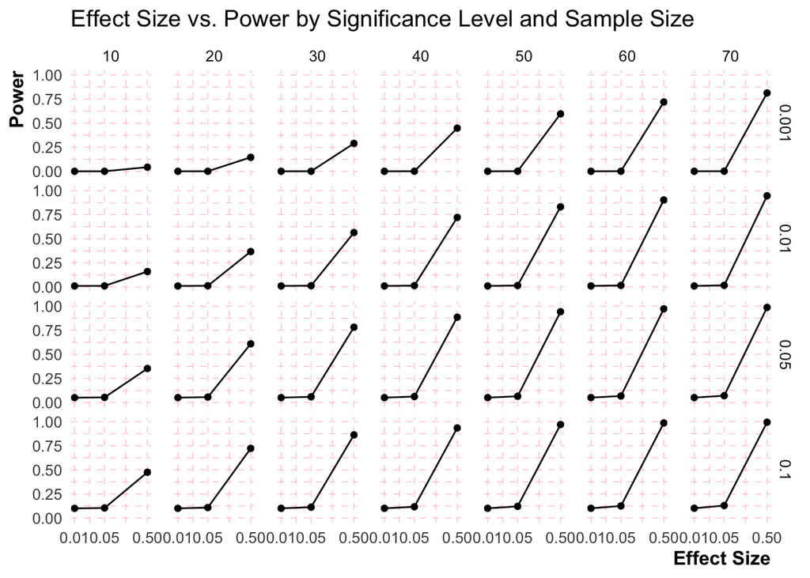

```r
# Create a line plot with points for each combination of significance level and sample size
ggplot(
  df,
  aes(
    x = effect_size,
    y = power,
    group = sample_size
  )
) +
  geom_line() +
  geom_point() +
  facet_grid(
    significance_level ~ sample_size,
    scales = "free"
  ) +
  labs(
    x = "Effect Size",
    y = "Power"
  ) +
  ggtitle(
    "Effect Size vs. Power by Significance Level and Sample Size"
  ) +
  my_theme() +
  theme(
    panel.spacing.x = unit(1, "lines")
  ) +
  scale_x_log10(
    breaks = c(0.01, 0.05, 0.5)
  ) +
  ylim(0, 1)
```

```r
# save plot
ggsave(
  here(
    "output", "segregation", "figures", "power_segregation.pdf"
  ),
  width = 8,
  height = 5,
  units = "in"
)
```

## 8. Estimate power for our data

The power estimation code uses Cohen’s w (effect size measure for chi-square test), which is calculated based on the difference between observed and expected frequencies. This does not directly apply the chi-square test, but uses the calculation based on chi-square distribution to estimate power.

```r
# Define parameters for power analysis
effect_size <- 0.01  # Desired effect size
significance_level <- 0.05  # Chosen significance level

# Create an empty tibble to store the results
results <- tibble(
  Family = character(),
  SNP = character(),
  Expected_A1_count = numeric(),
  Observed_A1_count = numeric(),
  Power_A1 = numeric(),
  Expected_A2_count = numeric(),
  Observed_A2_count = numeric(),
  Power_A2 = numeric()
)

# Perform power analysis for each family
for (i in 1:length(family_names)) {
  family <- family_names[i]

  family_parents <- family_parents_2[[i]]
  family_offspring <- family_offspring_2[[i]]

  # Find common SNPs between parents and offspring for the current family
  common_snps <- intersect(family_parents$SNP, family_offspring$SNP)

  # Iterate over each common SNP
  for (snp in common_snps) {
    # Subset parents and offspring data frames to include only the current SNP
    family_parents_snp <- subset(family_parents, SNP == snp)
    family_offspring_snp <- subset(family_offspring, SNP == snp)

    # Check if the subset resulted in any rows
    if (nrow(family_parents_snp) == 0 || nrow(family_offspring_snp) == 0) {
      next  # Skip to the next SNP
    }

    # Retrieve observed genotype frequencies in offspring
    observed_A1 <- family_offspring_snp$Observed_A1_count
    observed_A2 <- family_offspring_snp$Observed_A2_count

    # Retrieve expected genotype frequencies in parents
    expected_A1 <- family_parents_snp$Expected_A1_count
    expected_A2 <- family_parents_snp$Expected_A2_count

    # Perform power analysis for genotype A1
    power_A1 <- pwr.chisq.test(
      w = sum((observed_A1 - expected_A1)^2 / expected_A1),
      N = family_offspring_snp$NCHROBS[1],
      df = 1,
      sig.level = significance_level,
      power = NULL
    )$power

    # Perform power analysis for genotype A2
    power_A2 <- pwr.chisq.test(
      w = sum((observed_A2 - expected_A2)^2 / expected_A2),
      N = family_offspring_snp$NCHROBS[1],
      df = 1,
      sig.level = significance_level,
      power = NULL
    )$power

    # Store the results in the tibble
    result <- tibble(
      Family = family,
      SNP = snp,
      Expected_A1_count = sum(expected_A1),
      Observed_A1_count = sum(observed_A1),
      Power_A1 = power_A1,
      Expected_A2_count = sum(expected_A2),
      Observed_A2_count = sum(observed_A2),
      Power_A2 = power_A2
    )
    results <- bind_rows(results, result)
  }
}

# view the results
# head(results)

# Convert head(results) to a tibble
table_result <- as_tibble(head(results))

# Create a flextable object
flex_table <- flextable(table_result)

# Set the formatting options if needed
# flex_table <- flex_table %>%
#   theme_box()  # Example of adding a border around the table

# Print the flextable
flex_table
```

| Family | SNP | Expected_A1_count | Observed_A1_count | Power_A1 | Expected_A2_count | Observed_A2_count | Power_A2 |
| --- | --- | --- | --- | --- | --- | --- | --- |
| family_16 | AX-93213918 | 46.5 | 50.0030 | 0.54696499 | 15.5 | 11.9970 | 0.99999039 |
| family_16 | AX-93213924 | 46.5 | 55.0002 | 1.00000000 | 15.5 | 6.9998 | 1.00000000 |
| family_16 | AX-93213930 | 45.0 | 43.9980 | 0.05342841 | 15.0 | 16.0020 | 0.08132005 |
| family_16 | AX-93213933 | 28.0 | 28.0000 | 0.05000000 | 28.0 | 28.0000 | 0.05000000 |
| family_16 | AX-93213937 | 46.5 | 45.9978 | 0.05020895 | 15.5 | 16.0022 | 0.05188247 |
| family_16 | AX-93213944 | 46.5 | 45.9978 | 0.05020895 | 15.5 | 16.0022 | 0.05188247 |

```r
summary(results)
```

```
##     Family              SNP            Expected_A1_count Observed_A1_count
##  Length:31226       Length:31226       Min.   : 0.50     Min.   : 0.00
##  Class :character   Class :character   1st Qu.:30.00     1st Qu.:28.00
##  Mode  :character   Mode  :character   Median :32.00     Median :35.00
##                                        Mean   :34.59     Mean   :34.92
##                                        3rd Qu.:46.50     3rd Qu.:46.00
##                                        Max.   :48.00     Max.   :64.00
##     Power_A1       Expected_A2_count Observed_A2_count    Power_A2
##  Min.   :0.05000   Min.   : 1.00     Min.   : 0.00     Min.   :0.05000
##  1st Qu.:0.05188   1st Qu.:15.50     1st Qu.:15.00     1st Qu.:0.05188
##  Median :0.18459   Median :28.00     Median :24.00     Median :0.51346
##  Mean   :0.44552   Mean   :25.77     Mean   :25.44     Mean   :0.51602
##  3rd Qu.:0.99999   3rd Qu.:31.00     3rd Qu.:32.00     3rd Qu.:1.00000
##  Max.   :1.00000   Max.   :48.00     Max.   :64.00     Max.   :1.00000
```

## 9. Number of SNPs genotyped per family

Each family is a cross of different populations. They have different sets of SNPs genotyped.

### 9.1 Venn diagram

We can make a Venn diagram to represent the shared and unique SNPs across all families.

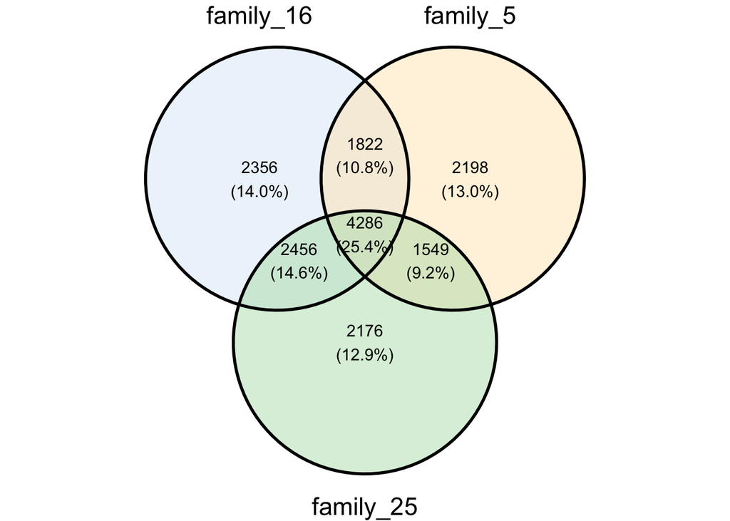

```r
# Read in the SNP data for each family
family_names <-
  names(family_parents_2)

family_parents_vectors <-
  lapply(
    family_parents_2, function(df) {
      df$SNP
    }
  )

family_offspring_vectors <-
  lapply(
    family_offspring_2, function(df) {
      df$SNP
    }
  )

# Calculate shared SNPs among the families
family_shared_SNPs <-
  Reduce(
    intersect,
    family_parents_vectors
  )

# Create Venn diagram data
venn_data <-
  setNames(
    family_parents_vectors,
    family_names
  )

# Create Venn diagram
venn_plot <-
  ggvenn(
    venn_data,
    fill_color = c(
      "#DCEAF7", "#FFE6BF", "#B7E0B7"
    ),
    show_percentage = TRUE
  ) +
  theme_void()

# Adjust font size and label visibility
venn_plot <-
  venn_plot +
  theme(
    text = element_text(
      size = 8
    ),
    # Adjust the font size
    plot.title = element_text(
      hjust = 0.5,
      size = 12
    ),
    # Adjust the font size and center the plot title
    legend.text = element_text(
      size = 2
    ),
    # Adjust the legend font size
    legend.key.size = unit(
      0.5, "lines"
    ),
    # Reduce the size of the legend keys
    legend.spacing = unit(
      0.2, "lines"
    ) # Reduce the spacing between legend items
  )

# Display the Venn diagram
print(venn_plot)
```

```r
# Save Venn diagram to PDF
ggsave(
  here(
    "output",
    "segregation",
    "figures",
    "shared_SNPs_families.pdf"
  ),
  venn_plot,
  height = 5,
  width = 5,
  dpi = 300
)
```

### 9.2 Segregation table

```r
# Calculate shared SNPs among the families
family_shared_SNPs <-
  Reduce(
    intersect,
    family_parents_vectors
  )

# Calculate the number and percentage of shared SNPs for each family
n_shared_SNPs <-
  length(family_shared_SNPs)

p_shared_SNPs <-
  sapply(
    family_parents_vectors, function(vector) {
      n_shared_SNPs / length(vector) * 100
    }
  )

# Calculate unique SNPs for each family
family_unique_SNPs <-
  lapply(
    family_parents_vectors, function(vector) {
      setdiff(
        vector, family_shared_SNPs
      )
    }
  )

names(family_unique_SNPs) <-
  family_names

# Calculate the number and percentage of unique SNPs for each family
n_unique_SNPs <-
  sapply(
    family_unique_SNPs,
    length
  )
p_unique_SNPs <-
  sapply(
    family_unique_SNPs, function(vector) {
      length(vector) / length(family_parents_vectors[[1]]) * 100
    }
  )

# Calculate the total number of SNPs for each family
n_total_SNPs <-
  sapply(
    family_parents_vectors, length
  )

# Create a data frame with the data
table_data <- data.frame(
  Family = family_names,
  n_total_SNPs = n_total_SNPs,
  n_shared_SNPs = rep(n_shared_SNPs, length(family_names)),
  p_shared_SNPs = round(p_shared_SNPs, 2),
  n_unique_SNPs = n_unique_SNPs,
  p_unique_SNPs = round(p_unique_SNPs, 2)
)

# Create a flextable object
flex_table <-
  flextable::flextable(
    table_data
  )

# show table
flex_table
```

| Family | n_total_SNPs | n_shared_SNPs | p_shared_SNPs | n_unique_SNPs | p_unique_SNPs |
| --- | --- | --- | --- | --- | --- |
| family_16 | 10,920 | 4,286 | 39.25 | 6,634 | 60.75 |
| family_5 | 9,855 | 4,286 | 43.49 | 5,569 | 51.00 |
| family_25 | 10,467 | 4,286 | 40.95 | 6,181 | 56.60 |

```r
# Save the Word document
flextable::save_as_docx(
  flex_table,
  path = here(
    "output",
    "segregation",
    "figures",
    "segregating_SNPs_table.docx"
  )
)
```

We can save the data as RDS format to load it later if necessary. To save the data

```r
# Save the data
saveRDS(
  family_parents_2,
  file = here(
    "output", "segregation", "figures", "family_parents_2.rds"
  )
)
saveRDS(
  family_offspring_2,
  file = here(
    "output", "segregation", "figures", "family_offspring_2.rds"
  )
)
```

To load the data

```r
# Load the data later
family_parents_2 <-
  readRDS(
    file = here(
      "output", "segregation", "figures", "family_parents_2.rds"
    )
  )
family_offspring_2 <-
  readRDS(
    file = here(
      "output", "segregation", "figures", "family_offspring_2.rds"
    )
  )
```

## 10. Chi square test

Do a chi square test for each family, obtain p values, store them in tibble, use Fisher test to combine the p values across the families. However, the number of SNPs in each family is different. So, if a SNP is in only one family, it is okay to have only one p values. Let’s do the chi square and the fisher test to combine the p values.

### 10.1 Remove SNPs with zeros or counts < 5

We can remove SNPs with zero and <5 counts if you want. Check below how many SNPs we would remove. I did not remove it for the test. I just wanted to know how many SNPs we would remove.

```r
# Creating new data sets excluding rows with counts less than 5 in parents and offspring
family_parents_5 <-
  lapply(
    family_parents_2, function(df) {
      df[!(df$Expected_A1_count < 5 | df$Expected_A2_count < 5), ]
    }
  )

family_offspring_5 <-
  lapply(
    family_offspring_2, function(df) {
      df[!(df$Observed_A1_count < 5 | df$Observed_A2_count < 5), ]
    }
  )
```

### 10.2 Sanity checks after data tyding

Now check again for discrepancies, we will use the data set without counts smaller than 5

```r
# Create an empty vector to store families with discrepancies
families_with_discrepancies <- c()

# Loop over each family in the parents and offspring list
for (family in names(family_parents_5)) {

  # Extract the parent and offspring data for the current family
  parent_data <- family_parents_5[[family]]
  offspring_data <- family_offspring_5[[family]]

  # Check if the number of rows (observations) is the same for both parents and offspring
  if (nrow(parent_data) != nrow(offspring_data)) {
    cat(paste("Number of observations differs for family", family, "\n"))
  }

  # Check if the SNP ids are the same for both parents and offspring and are in the same order
  if (!identical(parent_data$SNP, offspring_data$SNP)) {
    # Calculate number of discrepancies
    discrepancies <- sum(parent_data$SNP != offspring_data$SNP)
    cat(paste("SNP ids and/or order differ for family", family, "with", discrepancies, "discrepancies. \n"))
    # Append the family name to the vector
    families_with_discrepancies <- c(families_with_discrepancies, family)
  }
}
```

```
## Number of observations differs for family family_16
```

```
## SNP ids and/or order differ for family family_16 with 10886 discrepancies.
## Number of observations differs for family family_5
```

```
## SNP ids and/or order differ for family family_5 with 9833 discrepancies.
## Number of observations differs for family family_25
```

```
## SNP ids and/or order differ for family family_25 with 10441 discrepancies.
```

```r
# Output families with discrepancies
families_with_discrepancies
```

```
## [1] "family_16" "family_5"  "family_25"
```

Because we remove the SNPs with counts below 5, the length and the SNPs between parental and offspring data sets is different. We can fix it with the code we used before.

```r
# Initialize two empty lists to store the resulting data frames
family_parents_6 <- list()
family_offspring_6 <- list()

# Loop over each family
for (family in names(family_parents_5)) {

  # Extract the parent and offspring data for the current family
  parent_data <- family_parents_5[[family]]
  offspring_data <- family_offspring_5[[family]]

  # Perform an inner join based on SNP column to find common SNPs
  common_data <- merge(parent_data, offspring_data, by = "SNP")

  # Find the rows in the parent and offspring data that have the common SNPs
  parent_data_common <- parent_data[parent_data$SNP %in% common_data$SNP, ]
  offspring_data_common <- offspring_data[offspring_data$SNP %in% common_data$SNP, ]

  # Sort the data frames by the SNP column
  parent_data_common <- parent_data_common[order(parent_data_common$SNP), ]
  offspring_data_common <- offspring_data_common[order(offspring_data_common$SNP), ]

  # Store the resulting data frames in the corresponding lists
  family_parents_6[[family]] <- parent_data_common
  family_offspring_6[[family]] <- offspring_data_common
}
```

Now check again for discrepancies again

```r
# Create an empty vector to store families with discrepancies
families_with_discrepancies <- c()

# Loop over each family in the parents and offspring list
for (family in names(family_parents_6)) {

  # Extract the parent and offspring data for the current family
  parent_data <- family_parents_6[[family]]
  offspring_data <- family_offspring_6[[family]]

  # Check if the number of rows (observations) is the same for both parents and offspring
  if (nrow(parent_data) != nrow(offspring_data)) {
    cat(paste("Number of observations differs for family", family, "\n"))
  }

  # Check if the SNP ids are the same for both parents and offspring and are in the same order
  if (!identical(parent_data$SNP, offspring_data$SNP)) {
    # Calculate number of discrepancies
    discrepancies <- sum(parent_data$SNP != offspring_data$SNP)
    cat(paste("SNP ids and/or order differ for family", family, "with", discrepancies, "discrepancies. \n"))
    # Append the family name to the vector
    families_with_discrepancies <- c(families_with_discrepancies, family)
  }
}

# Output families with discrepancies
families_with_discrepancies
```

We can compare how many SNPs we are removing from data sets once we remove the SNPs with counts below 5. Since we have the same SNPs in parents and offspring, we can check only one of the data sets before and after remove the SNPs low allele counts.

```r
# Calculate the number of removed SNPs for each family
removed_snps <-
  sapply(seq_along(family_parents_5), function(i) {
  nrow(family_parents_5[[i]]) - nrow(family_parents_6[[i]])
})

# Calculate total unique SNPs before and after filtering
unique_snps_before <-
  unique(unlist(lapply(family_parents_5, `[[`, "SNP")))
unique_snps_after <-
  unique(unlist(lapply(family_parents_6, `[[`, "SNP")))

# Calculate number of SNPs before and after for each family
snps_before <-
  sapply(family_parents_5, function(df)
  nrow(df))
snps_after <-
  sapply(family_parents_6, function(df)
  nrow(df))

# Calculate percentage of SNPs removed for each family and across all families
percentage_removed <-
  removed_snps / snps_before * 100
percentage_removed_all <-
  length(setdiff(unique_snps_before, unique_snps_after)) / length(unique_snps_before) * 100

# Format percentage values with two decimal places
percentage_removed <-
  sprintf("%.2f", percentage_removed)
percentage_removed_all <-
  sprintf("%.2f", percentage_removed_all)

# Create a tibble with the results
results <-
  tibble(
  Family = as.character(1:length(removed_snps)),
  SNPs_Before = snps_before,
  SNPs_After = snps_after,
  SNPs_Removed = removed_snps,
  Percentage_Removed = percentage_removed
)

# Calculate the total number of unique SNPs removed across all families
total_snps_removed <-
  length(setdiff(unique_snps_before, unique_snps_after))

# Add total row to the tibble
total_row <-
  tibble(
  Family = "Total",
  SNPs_Before = length(unique_snps_before),
  SNPs_After = length(unique_snps_after),
  SNPs_Removed = total_snps_removed,
  Percentage_Removed = percentage_removed_all
)
# Bind objects
results <-
  bind_rows(results, total_row)

# Set theme
set_flextable_defaults(
  font.family = "Arial",
  font.size = 9,
  big.mark = ",",
  theme_fun = "theme_zebra" # try the themes: theme_alafoli(), theme_apa(), theme_booktabs(), theme_box(), theme_tron_legacy(), theme_tron(), theme_vader(), theme_vanilla(), theme_zebra()
)

# Create the flextable object to save as .docx
flex_table <-
  flextable(results) |>
  set_caption(caption = as_paragraph(
    as_chunk(
      "Table 5. Number of SNPs before and after removing SNPs with allele count below 5.",
      props = fp_text_default(color = "#000000", font.size = 12)
    )
  ),
  fp_p = fp_par(text.align = "center", padding = 5))

# Print the table Markdown
flex_table
```

Table 5. Number of SNPs before and after removing SNPs with allele count below 5.

| Family | SNPs_Before | SNPs_After | SNPs_Removed | Percentage_Removed |
| --- | --- | --- | --- | --- |
| 1 | 10,899 | 10,584 | 315 | 2.89 |
| 2 | 9,840 | 9,556 | 284 | 2.89 |
| 3 | 10,453 | 10,215 | 238 | 2.28 |
| Total | 16,815 | 16,466 | 349 | 2.08 |

```r
# Save the Word document
flextable::save_as_docx(flex_table,
                        path = here(
                          "output",
                          "segregation",
                          "figures",
                          "filtering_results.docx"
                        ))
```

Now we can do our test. Since we have thousands of SNPs, lets subset to create a small data set to test the code for the statistical analyses

```r
# Subset the data to get the first 100 SNPs
family_parents_6_subset_no_zeros <- lapply(family_parents_6, function(df) df[1:100, ])
family_offspring_6_subset_no_zeros <- lapply(family_offspring_6, function(df) df[1:100, ])

# Verify the result data
# str(family_parents_6_subset_no_zeros)
# str(family_offspring_6_subset_no_zeros)
```

We can save the data as RDS format to load it later if necessary. To save the data

```r
# Save the data
saveRDS(
  family_parents_6_subset_no_zeros,
  file = here(
    "output", "segregation", "figures", "family_parents_6_subset_no_zeros.rds"
  )
)
saveRDS(
  family_offspring_6_subset_no_zeros,
  file = here(
    "output", "segregation", "figures", "family_offspring_6_subset_no_zeros.rds"
  )
)
```

We can also subset the original data and keep the counts below 5.

```r
# Subset the data to get the first 100 SNPs
family_parents_6_subset_with_zeros <- lapply(family_parents_2, function(df) df[1:100, ])
family_offspring_6_subset_with_zeros <- lapply(family_offspring_2, function(df) df[1:100, ])

# Verify the subsetted data
# str(family_parents_6_subset_with_zeros)
# str(family_offspring_6_subset_with_zeros)
```

Check for discrepancies

```r
# Create an empty vector to store families with discrepancies
families_with_discrepancies <- c()

# Loop over each family in the parents and offspring list
for (family in names(family_parents_6_subset_with_zeros)) {

  # Extract the parent and offspring data for the current family
  parent_data <- family_parents_6_subset_with_zeros[[family]]
  offspring_data <- family_offspring_6_subset_with_zeros[[family]]

  # Check if the number of rows (observations) is the same for both parents and offspring
  if (nrow(parent_data) != nrow(offspring_data)) {
    cat(paste("Number of observations differs for family", family, "\n"))
  }

  # Check if the SNP ids are the same for both parents and offspring and are in the same order
  if (!identical(parent_data$SNP, offspring_data$SNP)) {
    # Calculate number of discrepancies
    discrepancies <- sum(parent_data$SNP != offspring_data$SNP)
    cat(paste("SNP ids and/or order differ for family", family, "with", discrepancies, "discrepancies. \n"))
    # Append the family name to the vector
    families_with_discrepancies <- c(families_with_discrepancies, family)
  }
}

# Output families with discrepancies
families_with_discrepancies
```

```r
# Save the data
saveRDS(
  family_parents_6_subset_with_zeros,
  file = here(
    "output", "segregation", "figures", "family_parents_6_subset_with_zeros.rds"
  )
)
saveRDS(
  family_offspring_6_subset_with_zeros,
  file = here(
    "output", "segregation", "figures", "family_offspring_6_subset_with_zeros.rds"
  )
)
```

Clean environment and memory

```r
rm(list = ls())
gc()
```

```
##            used  (Mb) gc trigger  (Mb) limit (Mb) max used  (Mb)
## Ncells 10914838 583.0   17815777 951.5         NA 17815777 951.5
## Vcells 19887219 151.8   32418135 247.4      32768 32418135 247.4
```

To load the data

```r
# Load the data with no counts below 5
family_parents_6_subset_no_zeros <-
  readRDS(
    file = here(
      "output", "segregation", "figures", "family_parents_6_subset_no_zeros.rds"
    )
  )
family_offspring_6_subset_no_zeros <-
  readRDS(
    file = here(
      "output", "segregation", "figures", "family_offspring_6_subset_no_zeros.rds"
    )
  )

# Load the data with counts below 5 and zeros
family_parents_6_subset_with_zeros <-
  readRDS(
    file = here(
      "output", "segregation", "figures", "family_parents_6_subset_with_zeros.rds"
    )
  )
family_offspring_6_subset_with_zeros <-
  readRDS(
    file = here(
      "output", "segregation", "figures", "family_offspring_6_subset_with_zeros.rds"
    )
  )
```

### 10.3 Segregation test

We will use the data without filtering.

**Code Explanation:**

1. **Data Frame Initialization:** Initializes an empty data frame named “combined_df” with specific column names and data types.
2. **Unique SNP Identification:** Identifies all unique Single Nucleotide Polymorphisms (SNPs) across all families.
3. **SNP Analysis Loop:** Begins a loop to perform statistical analysis for each SNP.
4. **Family Iteration:** Inside this loop, another loop is created to go through each family.
5. **SNP Presence Check:** For each family, the code checks if the current SNP is present in both parents and offspring.
6. **Statistical Tests:** Conducts Fisher’s exact test or Chi-square test depending on the observed and expected counts for the SNP alleles.
7. **P-Value Storage:** Stores the p-value from the statistical test.
8. **Data Frame Update:** Adds the details to the “combined_df” data frame for each family.
9. **Data Frame Transformation:** Uses “pivot_wider” to transform the data frame from a long format to a wide format, creating separate columns for each family and renaming them.
10. **Rows Merging:** Merges rows with same SNP, while preserving unique values in each family column, and places the count of families and combined p-value in the final data frame.
11. **Output Order Setting:** Sets the order of the columns in the output data frame.
12. **P-Value Combination:** Combines the p-values for each SNP across all families using a chi-square based method.
13. **Adjusted P-Values Calculation:** Calculates adjusted p-values using the Holm-Bonferroni method.
14. **P-Values Formatting:** Applies a custom function to format the p-values in a certain manner.
15. **Count Columns Rounding:** Rounds count columns to 2 decimal places.
16. **P-Values Conversion:** Converts the p-values to numeric and then applies custom formatting to these columns.
17. **Family Count Update:** Updates the count of families for each SNP.
18. **Results Conversion to Tibble:** Converts the final results data frame to a tibble for displaying.
19. **Flextable Creation:** Creates a flextable object to display the head of the results in a stylized format.

```r
# Initialize the combined data frame
combined_df <-
  data.frame(
    Family = character(),
    SNP = character(),
    Expected_A1_count = numeric(),
    Expected_A2_count = numeric(),
    Observed_A1_count = numeric(),
    Observed_A2_count = numeric(),
    P_Value = numeric(),
    Combined_P_Value = numeric(),
    Family_Count = integer(),
    stringsAsFactors = FALSE
  )

# Get all unique SNPs across all families - use _with_zeros or no_zeros to see how many SNPs
all_snps <-
  unique(
    unlist(
      lapply(
        family_parents_6_subset_with_zeros, function(x) {
          x$SNP
        }
      )
    )
  )

# Perform the analysis for each SNP
for (snp in all_snps) {
  p_values <- numeric()
  family_count <- 0
  families <- c()

  # Go through each family
  for (i in 1:length(family_parents_6_subset_with_zeros)) {
    family_parents <- family_parents_6_subset_with_zeros[[i]]
    family_offspring <- family_offspring_6_subset_with_zeros[[i]]

    # Check if the SNP is in the family
    if (snp %in% family_parents$SNP &&
      snp %in% family_offspring$SNP) {
      family_count <- family_count + 1
      families <- c(families, names(family_parents_6_subset_with_zeros)[i])

      # Conduct the chi-square test
      observed_counts <-
        c(
          family_offspring[family_offspring$SNP == snp, "Observed_A1_count"],
          family_offspring[family_offspring$SNP == snp, "Observed_A2_count"]
        )
      expected_counts <-
        c(
          family_parents[family_parents$SNP == snp, "Expected_A1_count"],
          family_parents[family_parents$SNP == snp, "Expected_A2_count"]
        )
      if (min(observed_counts, expected_counts) < 5) {
        # If either of the counts is less than 5, use Fisher's Exact Test
        test_result <- fisher.test(matrix(c(observed_counts, expected_counts), nrow = 2))$p.value
      } else {
        # Otherwise use Chi-Square Test
        test_result <- chisq.test(observed_counts, p = expected_counts / sum(expected_counts))$p.value
      }

      # Store the p-value
      p_values <- c(p_values, test_result)

      # Add the details to the data frame for each family
      combined_df <- rbind(
        combined_df,
        data.frame(
          Family = names(family_parents_6_subset_with_zeros)[i],
          SNP = snp,
          Expected_A1_count = family_parents[family_parents$SNP == snp, "Expected_A1_count"],
          Observed_A1_count = family_offspring[family_offspring$SNP == snp, "Observed_A1_count"],
          Expected_A2_count = family_parents[family_parents$SNP == snp, "Expected_A2_count"],
          Observed_A2_count = family_offspring[family_offspring$SNP == snp, "Observed_A2_count"],
          P_Value = test_result,
          Family_Count = family_count,
          # Assign the Family_Count here
          Combined_P_Value = NA,
          # As we haven't calculated combined p-value yet
          stringsAsFactors = FALSE
        )
      )
    }
  }

  # Skip if there's no SNP found in any family
  if (family_count == 0) {
    next
  }
}

new_df <- combined_df|>
  pivot_wider(names_from = Family, values_from = c(Expected_A1_count, Observed_A1_count, Expected_A2_count, Observed_A2_count, P_Value)) |>
  rename_with(~ gsub("(\\d+)_(Expected|Observed)", paste0("fam\\1_", "\\2"), .), starts_with("Expected")) |>
  rename_with(~ gsub("(\\d+)_(Expected|Observed)", paste0("fam\\1_", "\\2"), .), starts_with("Observed"))

# Merge rows
merged_df <-
  new_df |>
  group_by(SNP) %>%
  summarise(
    across(
      starts_with("Expected_A1_count_fam"),
      ~ ifelse(all(is.na(.)), NA, unique(.[!is.na(.)])[1])
    ),
    across(
      starts_with("Observed_A1_count_fam"),
      ~ ifelse(all(is.na(.)), NA, unique(.[!is.na(.)])[1])
    ),
    across(
      starts_with("Expected_A2_count_fam"),
      ~ ifelse(all(is.na(.)), NA, unique(.[!is.na(.)])[1])
    ),
    across(
      starts_with("Observed_A2_count_fam"),
      ~ ifelse(all(is.na(.)), NA, unique(.[!is.na(.)])[1])
    ),
    across(
      starts_with("P_Value_fam"),
      ~ ifelse(all(is.na(.)), NA, unique(.[!is.na(.)])[1])
    ),
    Family_Count = first(Family_Count),
    Combined_P_Value = first(Combined_P_Value)
  ) %>%
  ungroup() %>%
  dplyr::select(
    SNP,
    starts_with("Expected_A1_count_fam"),
    starts_with("Expected_A2_count_fam"),
    starts_with("Observed_A1_count_fam"),
    starts_with("Observed_A2_count_fam"),
    starts_with("P_Value_fam"),
    Family_Count,
    Combined_P_Value
  )

# set ouput order
merged_df <-
  merged_df |>
  dplyr::select(SNP,
         starts_with("Expected_A1_count_family_25"),
         starts_with("Observed_A1_count_family_25"),
         starts_with("Expected_A2_count_family_25"),
         starts_with("Observed_A2_count_family_25"),
         starts_with("P_Value_family_25"),
         starts_with("Expected_A1_count_family_16"),
         starts_with("Observed_A1_count_family_16"),
         starts_with("Expected_A2_count_family_16"),
         starts_with("Observed_A2_count_family_16"),
         starts_with("P_Value_family_16"),
         starts_with("Expected_A1_count_family_5"),
         starts_with("Observed_A1_count_family_5"),
         starts_with("Expected_A2_count_family_5"),
         starts_with("Observed_A2_count_family_5"),
         starts_with("P_Value_family_5"),
         Family_Count,
         Combined_P_Value)

#
# Combine the p values


# Option 1: using fisher.test()

# Create new columns for Combined_P_Value and Adjusted_P_Value
merged_df$Combined_P_Value <- NA
merged_df$Adjusted_P_Value <- NA

# Iterate over each row
# for (i in 1:nrow(merged_df)) {
#   p_values <- numeric()
#
#   # Check P-values in each family column
#   for (j in 1:6) {
#     col_name <- paste0("P_Value_fam", j)
#     if (!is.na(merged_df[i, col_name])) {
#       p_value <- as.numeric(merged_df[i, col_name])
#       if (!is.na(p_value)) {
#         p_values <- c(p_values, p_value)
#       }
#     }
#   }
#
#   # Combine P-values if more than one is present - using fisher.test
#   if (length(p_values) > 1) {
#     contingency_table <- matrix(c(sum(1 - p_values), sum(p_values), sum(p_values), sum(1 - p_values)), ncol = 2)
#     combined_p_value <- fisher.test(contingency_table)$p.value
#     merged_df[i, "Combined_P_Value"] <- combined_p_value
#   } else if (length(p_values) == 1) {
#     merged_df[i, "Combined_P_Value"] <- p_values
#   }
# }
#
# Option 2: using chi-square
# Iterate over each row
for (i in 1:nrow(merged_df)) {
  p_values <- numeric()

  # Check P-values in each family column
  for (j in c(5, 16, 25)) {
    col_name <- paste0("P_Value_family_", j)
    if (!is.na(merged_df[i, col_name])) {
      p_value <- as.numeric(merged_df[i, col_name])
      if (!is.na(p_value)) {
        p_values <- c(p_values, p_value)
      }
    }
  }

  # Combine P-values if more than one is present
  if (length(p_values) > 1) {
    combined_p_value <- pchisq(
      -2 * sum(log(p_values)),
      df = 2 * length(p_values),
      lower.tail = FALSE
    )
    merged_df[i, "Combined_P_Value"] <- combined_p_value
  } else if (length(p_values) == 1) {
    merged_df[i, "Combined_P_Value"] <- p_values
  }
}

# Calculate Adjusted P-values
adjusted_p_values <- p.adjust(merged_df$Combined_P_Value, method = "holm")
merged_df$Adjusted_P_Value <- adjusted_p_values


# Custom formatting function for p-values
format_pvalues <- function(x) {
  ifelse(x < 0.001, formatC(x, format = "e", digits = 2),
         ifelse(x >= 0.001 & x < 1, round(x, 3),
                ifelse(x == 1, "1", format(x, scientific = FALSE))))
}

# Apply custom formatting to Combined_P_Value and Adjusted_P_Value columns
merged_df[c("Combined_P_Value", "Adjusted_P_Value")] <- lapply(merged_df[c("Combined_P_Value", "Adjusted_P_Value")], format_pvalues)

# Get a vector of column names containing "_count"
count_columns <- grep("_count", colnames(merged_df), value = TRUE)

# Iterate over these columns, and round each to 2 decimal places
merged_df <- merged_df |>
  mutate(across(all_of(count_columns), ~ round(., digits = 2)))

# Get a vector of column names starting with "P_Value_fam"
pvalue_columns <- grep("^P_Value_fam", colnames(merged_df), value = TRUE)

# Convert P_Value columns to numeric
merged_df <-
  merged_df |>
  mutate(across(all_of(pvalue_columns), as.numeric))

# Apply custom formatting to P_Value columns
merged_df[pvalue_columns] <-
  lapply(merged_df[pvalue_columns], format_pvalues)

# Update the counts
pvalue_columns <-
  grep("P_Value_fam", colnames(merged_df), value = TRUE)

merged_df <-
  merged_df |>
  mutate(
    Family_Count = rowSums(!is.na(across(all_of(pvalue_columns))))
  )

# Convert head(results) to a tibble
table_result <-
  as_tibble(merged_df)

# Set theme if you want to use something different from the previous table
set_flextable_defaults(
  font.family = "Arial",
  font.size = 9,
  big.mark = ",",
  theme_fun = "theme_zebra" # try the themes: theme_alafoli(), theme_apa(), theme_booktabs(), theme_box(), theme_tron_legacy(), theme_tron(), theme_vader(), theme_vanilla(), theme_zebra()
)

# Then create the flextable object
flex_table <-
flextable(head(table_result)) |>
  set_caption(caption = as_paragraph(
    as_chunk(
      "Table 6. Output of 100 SNPs to test our code (header) .",
      props = fp_text_default(color = "#000000", font.size = 14)
    )
  ),
  fp_p = fp_par(text.align = "center", padding = 5))

# Print the flextable
flex_table
```

Table 6. Output of 100 SNPs to test our code (header) .

| SNP | Expected_A1_count_family_25 | Observed_A1_count_family_25 | Expected_A2_count_family_25 | Observed_A2_count_family_25 | P_Value_family_25 | Expected_A1_count_family_16 | Observed_A1_count_family_16 | Expected_A2_count_family_16 | Observed_A2_count_family_16 | P_Value_family_16 | Expected_A1_count_family_5 | Observed_A1_count_family_5 | Expected_A2_count_family_5 | Observed_A2_count_family_5 | P_Value_family_5 | Family_Count | Combined_P_Value | Adjusted_P_Value |
| --- | --- | --- | --- | --- | --- | --- | --- | --- | --- | --- | --- | --- | --- | --- | --- | --- | --- | --- |
| AX-93213914 | 15.5 | 16 | 46.5 | 46 | 0.883 |  |  |  |  |  |  |  |  |  |  | 1 | 0.883 | 1 |
| AX-93213918 | 31.0 | 30 | 31.0 | 32 | 0.8 | 46.5 | 50 | 15.5 | 12 | 0.304 |  |  |  |  |  | 2 | 0.587 | 1 |
| AX-93213920 | 46.5 | 36 | 15.5 | 26 | 0.002 |  |  |  |  |  |  |  |  |  |  | 1 | 0.002 | 0.296 |
| AX-93213924 | 31.0 | 32 | 31.0 | 30 | 0.8 | 46.5 | 55 | 15.5 | 7 | 0.013 | 32 | 32 | 32 | 32 | 1 | 3 | 0.163 | 1 |
| AX-93213930 | 14.5 | 17 | 43.5 | 41 | 0.448 | 45.0 | 44 | 15.0 | 16 | 0.765 |  |  |  |  |  | 2 | 0.71 | 1 |
| AX-93213933 | 46.5 | 43 | 15.5 | 19 | 0.304 | 28.0 | 28 | 28.0 | 28 | 1 | 28 | 28 | 28 | 28 | 1 | 3 | 0.882 | 1 |

Select p values columns

```r
# Select columns with "SNP" and "P_Value" in the column name
selected_columns <- c("SNP", grep("P_Value", colnames(merged_df), value = TRUE), "Family_Count")

# Create a new dataframe with selected columns
selected_df <- merged_df[selected_columns]

# Reorder the columns in selected_df
# selected_df <- selected_df[, c(selected_columns[1:7], selected_columns[10], selected_columns[8], selected_columns[9])]

# Set theme if you want to use something different from the previous table
set_flextable_defaults(
  font.family = "Arial",
  font.size = 9,
  big.mark = ",",
  theme_fun = "theme_zebra" # try the themes: theme_alafoli(), theme_apa(), theme_booktabs(), theme_box(), theme_tron_legacy(), theme_tron(), theme_vader(), theme_vanilla(), theme_zebra()
)

# Then create the flextable object
flex_table <- flextable(head(selected_df)) |>
  set_caption(caption = as_paragraph(
    as_chunk(
      "Table 6. Output of 100 SNPs to test our code (header).",
      props = fp_text_default(color = "#000000", font.size = 14)
    )
  ),
  fp_p = fp_par(text.align = "center", padding = 5))

# Print the flextable
flex_table
```

Table 6. Output of 100 SNPs to test our code (header).

| SNP | P_Value_family_25 | P_Value_family_16 | P_Value_family_5 | Combined_P_Value | Adjusted_P_Value | Family_Count |
| --- | --- | --- | --- | --- | --- | --- |
| AX-93213914 | 0.883 |  |  | 0.883 | 1 | 1 |
| AX-93213918 | 0.8 | 0.304 |  | 0.587 | 1 | 2 |
| AX-93213920 | 0.002 |  |  | 0.002 | 0.296 | 1 |
| AX-93213924 | 0.8 | 0.013 | 1 | 0.163 | 1 | 3 |
| AX-93213930 | 0.448 | 0.765 |  | 0.71 | 1 | 2 |
| AX-93213933 | 0.304 | 1 | 1 | 0.882 | 1 | 3 |

Save the results in Excel format

```r
# Specify the path and file name for the Excel file
excel_file <-
  here("output",
       "segregation",
       "figures",
       "results_pvalues_100_SNPs_01.xlsx")

# Create an empty Excel workbook
wb <- openxlsx::createWorkbook()

# Create a worksheet in the workbook
openxlsx::addWorksheet(wb, sheetName = "Results")

# Write the data frame to the worksheet
openxlsx::writeData(wb, sheet = "Results", selected_df)

# Save the workbook as an Excel file
openxlsx::saveWorkbook(wb, file = excel_file, overwrite = TRUE)
```

We can check the range of the p-values

```r
# Calculate the range for each column (excluding SNP)
column_ranges <-
  selected_df |>
  dplyr::select(-SNP) |>
  reframe(
    across(
      .cols = everything(),
      .fns = list(
        range = ~ range(as.numeric(.), na.rm = TRUE)
      ),
      .names = "{.col}_{.fn}"
    )
  )

# Print the column ranges
print(column_ranges)
```

```
## # A tibble: 2 × 6
##   P_Value_family_25_range P_Value_family_16_range P_Value_family_5_range
##                     <dbl>                   <dbl>                  <dbl>
## 1                4.14e-11                5.88e-12               2.48e-12
## 2                1   e+ 0                1   e+ 0               1   e+ 0
## # ℹ 3 more variables: Combined_P_Value_range <dbl>,
## #   Adjusted_P_Value_range <dbl>, Family_Count_range <dbl>
```

We see values from 0 to 1. I created a format function to make zero as 0 and not 00e+00, values from 0 to 0.001 will have scientific notation, 0.001 to 1 will have 3 decimals (rounded).

Check how many SNPs we tested. Remember, each family has a different set of SNPs. So, we end up testing more than 170 SNPs.

```r
length(
  unique(
    selected_df$SNP
  )
)
```

```
## [1] 177
```

The p-value is a measure of the likelihood that the observed difference from expected occurred due to random chance. A higher p-value suggests the frequencies could be randomly distributed, while a lower p-value suggests non-random distribution. The conventional threshold to decide whether a result is statistically significant is often set at 0.05.

In this case, you could consider those SNPs as randomly distributed whose adjusted p-value is more than 0.05 in all the families where they appear.

We can use the adjusted p values to filter out SNPs

```r
randomly_distributed_SNPs3 <-
  selected_df |>
  filter(Adjusted_P_Value > 0.05) |>
  pull(SNP) |>
  unique()

length(randomly_distributed_SNPs3)
```

```
## [1] 171
```

## 11. Sanity checks

Check the mim and max count values for each allele in each family

```r
# Define the list of variables
vars <-
  c(
    "Expected_A1_count",
    "Expected_A2_count",
    "Observed_A1_count",
    "Observed_A2_count"
  )

# Define the lists of data frames
dfs_parents <- list(
  fam1 = family_parents_6_subset_with_zeros$fam1,
  fam2 = family_parents_6_subset_with_zeros$fam2,
  fam3 = family_parents_6_subset_with_zeros$fam3,
  fam4 = family_parents_6_subset_with_zeros$fam4,
  fam5 = family_parents_6_subset_with_zeros$fam5,
  fam6 = family_parents_6_subset_with_zeros$fam6
)

dfs_offspring <- list(
  fam1 = family_offspring_6_subset_with_zeros$fam1,
  fam2 = family_offspring_6_subset_with_zeros$fam2,
  fam3 = family_offspring_6_subset_with_zeros$fam3,
  fam4 = family_offspring_6_subset_with_zeros$fam4,
  fam5 = family_offspring_6_subset_with_zeros$fam5,
  fam6 = family_offspring_6_subset_with_zeros$fam6
)

# Initialize the result lists
max_vals <- list()
min_vals <- list()

# Iterate over all variables
for (var in vars) {
  # Calculate the maximum values
  max_vals[[var]] <-
    max(sapply(dfs_parents, function(x)
      max(x[[var]])),
      sapply(dfs_offspring, function(x)
        max(x[[var]])))

  # Calculate the minimum values
  min_vals[[var]] <-
    min(sapply(dfs_parents, function(x)
      min(x[[var]])),
      sapply(dfs_offspring, function(x)
        min(x[[var]])))
}

# Print the maximum values
print(max_vals)
```

```
## $Expected_A1_count
## [1] -Inf
##
## $Expected_A2_count
## [1] -Inf
##
## $Observed_A1_count
## [1] -Inf
##
## $Observed_A2_count
## [1] -Inf
```

```r
# Print the minimum values
print(min_vals)
```

```
## $Expected_A1_count
## [1] Inf
##
## $Expected_A2_count
## [1] Inf
##
## $Observed_A1_count
## [1] Inf
##
## $Observed_A2_count
## [1] Inf
```

Check summary statistics

```r
# Define the function to calculate the mode
calc_mode <- function(x) {
  ux <- unique(x)
  ux[which.max(tabulate(match(x, ux)))]
}

# Define the function to calculate summary statistics
calc_summary_stats <- function(df, column) {
  summarise(
    df,
    Mean = mean(df[[column]], na.rm = TRUE),
    Median = median(df[[column]], na.rm = TRUE),
    Mode = calc_mode(df[[column]]), # Mode calculation updated
    Quantile_0_0.25 = quantile(df[[column]], 0.25, na.rm = TRUE),
    Quantile_0.25_0.5 = quantile(df[[column]], 0.5, na.rm = TRUE),
    Quantile_0.5_0.75 = quantile(df[[column]], 0.75, na.rm = TRUE),
    Quantile_0.75_1 = quantile(df[[column]], 1, na.rm = TRUE)
  )
}

# Initialize the table to store the results
table_result <- data.frame(
  Family = character(),
  Allele = character(),
  Mean = numeric(),
  Median = numeric(),
  Mode = numeric(),
  Quantile_0_0.25 = numeric(),
  Quantile_0.25_0.5 = numeric(),
  Quantile_0.5_0.75 = numeric(),
  Quantile_0.75_1 = numeric(),
  stringsAsFactors = FALSE
)


# Iterate over each family
for (i in names(family_parents_6_subset_with_zeros)) {
  family_parents <- family_parents_6_subset_with_zeros[[i]]
  family_offspring <- family_offspring_6_subset_with_zeros[[i]]

  # Get the SNPs shared between parents and offspring within the family
  shared_snps <- intersect(family_parents$SNP, family_offspring$SNP)

  # Filter the family dataset and offspring dataset to include only the shared SNPs
  family_parents_shared <- dplyr::filter(family_parents, SNP %in% shared_snps)
  family_offspring_shared <- dplyr::filter(family_offspring, SNP %in% shared_snps)

  # For each allele, calculate summary statistics and append them to the table
  for (allele in c("Expected_A1_count", "Observed_A1_count", "Expected_A2_count", "Observed_A2_count")) {
    if (grepl("Expected", allele)) {
      df <- family_parents_shared
    } else {
      df <- family_offspring_shared
    }

    summary_stats <- calc_summary_stats(df, allele)

    table_result <- bind_rows(
      table_result,
      data.frame(
        Family = i,
        Allele = allele,
        Mean = summary_stats$Mean,
        Median = summary_stats$Median,
        Mode = summary_stats$Mode,
        Quantile_0_0.25 = summary_stats$Quantile_0_0.25,
        Quantile_0.25_0.5 = summary_stats$Quantile_0.25_0.5,
        Quantile_0.5_0.75 = summary_stats$Quantile_0.5_0.75,
        Quantile_0.75_1 = summary_stats$Quantile_0.75_1
      )
    )
  }
}


# Create a flextable object
flex_table <- flextable(table_result)

# Print the flextable
flex_table
```

| Family | Allele | Mean | Median | Mode | Quantile_0_0.25 | Quantile_0.25_0.5 | Quantile_0.5_0.75 | Quantile_0.75_1 |
| --- | --- | --- | --- | --- | --- | --- | --- | --- |
| family_16 | Expected_A1_count | 35.34000 | 39.0000 | 46.5000 | 30.00000 | 39.0000 | 46.5000 | 46.5000 |
| family_16 | Observed_A1_count | 34.66024 | 38.0002 | 44.0014 | 28.00000 | 38.0002 | 45.9978 | 62.0000 |
| family_16 | Expected_A2_count | 23.76000 | 15.5000 | 15.5000 | 15.50000 | 15.5000 | 31.0000 | 46.5000 |
| family_16 | Observed_A2_count | 24.43976 | 17.9993 | 17.9986 | 14.99945 | 17.9993 | 31.0000 | 62.0000 |
| family_5 | Expected_A1_count | 35.28500 | 32.0000 | 32.0000 | 31.00000 | 32.0000 | 48.0000 | 48.0000 |
| family_5 | Observed_A1_count | 35.11993 | 32.0000 | 32.0000 | 27.99975 | 32.0000 | 47.2512 | 64.0000 |
| family_5 | Expected_A2_count | 26.03500 | 29.0000 | 32.0000 | 16.00000 | 29.0000 | 32.0000 | 48.0000 |
| family_5 | Observed_A2_count | 26.20007 | 26.0005 | 32.0000 | 16.00000 | 26.0005 | 32.0000 | 64.0000 |
| family_25 | Expected_A1_count | 34.01500 | 31.0000 | 46.5000 | 30.00000 | 31.0000 | 46.5000 | 46.5000 |
| family_25 | Observed_A1_count | 34.28996 | 31.9982 | 31.0000 | 25.74960 | 31.9982 | 43.2510 | 58.9998 |
| family_25 | Expected_A2_count | 26.48500 | 30.0000 | 15.5000 | 15.50000 | 30.0000 | 31.0000 | 46.5000 |
| family_25 | Observed_A2_count | 26.21004 | 25.0002 | 31.0000 | 17.00040 | 25.0002 | 31.0000 | 48.0004 |

Plot the stats

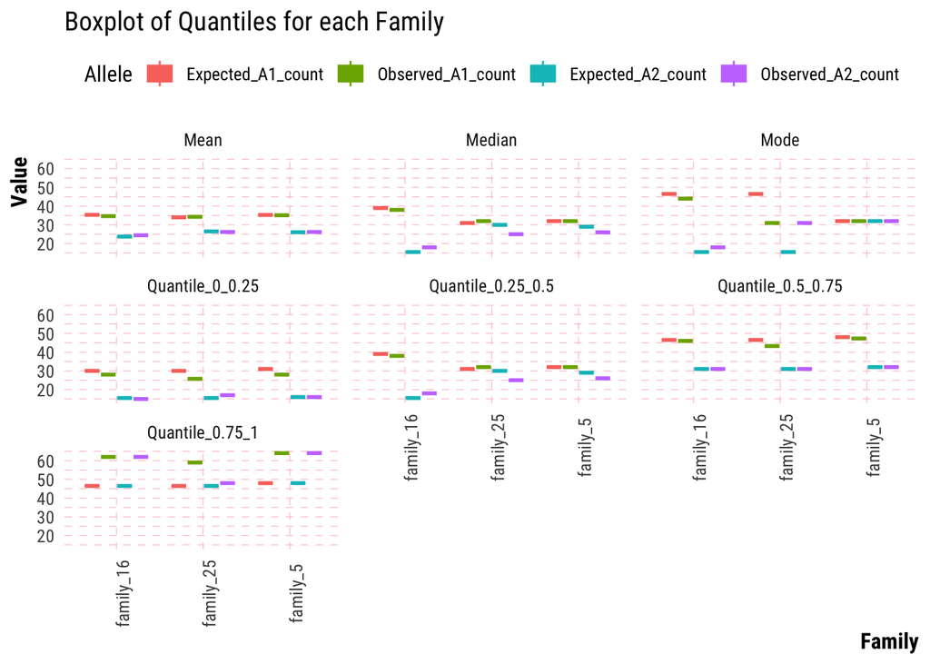

```r
# Reshape data for ggplot
table_result_long <- tidyr::pivot_longer(
  table_result,
  c(
    "Mean",
    "Median",
    "Mode",
    "Quantile_0_0.25",
    "Quantile_0.25_0.5",
    "Quantile_0.5_0.75",
    "Quantile_0.75_1"
  ),
  names_to = "Statistic",
  values_to = "Value"
)

# Source function theme
source(here("scripts", "analysis", "my_theme.R"))

# Define the desired order of the factor levels
allele_order <- c("Expected_A1_count", "Observed_A1_count", "Expected_A2_count", "Observed_A2_count")

# Convert the Allele variable to a factor with the desired order
table_result_long$Allele <- factor(table_result_long$Allele, levels = allele_order)


# Generate boxplot
p3 <-
  ggplot(table_result_long,
         aes(
           x = Family,
           y = Value,
           fill = Allele,
           color = Allele
         )) +
  facet_wrap(~ Statistic, scales = "fixed") +
  geom_boxplot() +
  my_theme() +
  theme(axis.text.x = element_text(angle = 90),
        legend.position = "top") +
  labs(title = "Boxplot of Quantiles for each Family", x = "Family", y = "Value")

# check plot
p3
```

```r
# Save Venn diagram to PDF
# output_path <-
#   here("output",
#        "segregation",
#        "albopictus",
#        "count_stats.pdf")
# ggsave(output_path,
#        p3,
#        height = 5,
#        width = 8,
#        dpi = 300)
```

## 12. Segregation test with all SNPs

I updated the code to use the library data.tabe and tried to make the code more efficient. It still take a long time to run, so I saved the output in .rds format.

Code summary:

**1. Initialize Data Table**

The script begins by initializing a ‘data.table’ named ‘combined_dt’ with the specified columns: Family, SNP, Expected_A1_count, Expected_A2_count, Observed_A1_count, Observed_A2_count, P_Value, Combined_P_Value, Family_Count. These columns will hold specific types of data (such as character, numeric, or integer).

**2. Extract Unique SNPs**

**3. Main Loop Over SNPs**

The main part of the script starts with a loop over all SNPs, in which each SNP is analyzed separately.

**4. Identify Families with the SNP**

For each SNP, the script identifies families that contain this SNP.

**5. Skip SNPs Not Present in Families**

If no family contains the SNP, the loop skips to the next SNP.

**6. Perform Statistical Tests**

If a family does contain the SNP, the script performs a statistical test (either Fisher’s Exact Test or Chi-Square Test, depending on the observed and expected counts) to compare the observed and expected counts of two alleles (A1 and A2) in the parents and the offspring.

**7. Add Results to Data Table**

The result of the statistical test and the data for the SNP (expected and observed counts, family name, etc.) are then added to the ‘combined_dt’.

**8. Save the Data**

After the loop over SNPs is finished, the ‘combined_dt’ is saved to an .rds file for future use.

**9. Widen the Data Frame**

Next, the script transforms ‘combined_dt’ into a wider format using the ‘pivot_wider()’ function. The new data frame ‘new_df’ contains separate columns for each family.

**10. Aggregate the Data**

Then, ‘new_df’ is aggregated into ‘merged_df’ by grouping by SNP and summarizing the columns.

**11. Calculate Combined P-Values**

In the next step, the script calculates a combined P-value for each SNP across all families. If more than one P-value is present for a SNP, they are combined using the Fisher’s method; if only one P-value is present, it is used as is.

**12. Adjust for Multiple Comparisons**

After that, the script adjusts the combined P-values for multiple comparisons using the Holm method.

**13. Apply Custom Formatting and Round Counts**

Then, the script applies custom formatting to P-values and rounds count values to 2 decimal places.

**14. Convert to Tibble**

After some more data transformations, the ‘merged_df’ is converted into a tibble ‘table_result’.

**15. Visualize the Data**

Finally, ‘table_result’ is visualized using the ‘flextable’ function to create a nicely formatted table.

### 12.1 Estimate p-values using chi-square test (count > 5) or Fisher test (counts < 5)

```r
# Initialize the data.table with the same columns as your data.frame
combined_dt <- data.table(
  Family = character(0),
  SNP = character(0),
  Expected_A1_count = numeric(0),
  Expected_A2_count = numeric(0),
  Observed_A1_count = numeric(0),
  Observed_A2_count = numeric(0),
  P_Value = numeric(0),
  Combined_P_Value = numeric(0),
  Family_Count = integer(0)
)


# Get all unique SNPs across all families - use _with_zeros or no_zeros to see how many SNPs
all_snps <-
  unique(unlist(lapply(family_parents_2, function(x) {
    x$SNP
  })))

# Perform the analysis for each SNP
for (snp in all_snps) {
  # Get the families that contain the SNP
  families_with_snp <- lapply(family_parents_2, function(family) {
    snp %in% family$SNP
  })
  families_with_snp_index <- unlist(families_with_snp)

  # Check if any family contains the SNP
  if (sum(families_with_snp_index) == 0) {
    next
  }

  # Go through each family that contains the SNP
  for (i in which(families_with_snp_index)) {
    family_parents <- family_parents_2[[i]]
    family_offspring <- family_offspring_2[[i]]

    # Check if the SNP is in the offspring
    if (snp %in% family_offspring$SNP) {
      # Conduct the chi-square test
      observed_counts <-
        c(family_offspring[family_offspring$SNP == snp, "Observed_A1_count"],
          family_offspring[family_offspring$SNP == snp, "Observed_A2_count"])
      expected_counts <-
        c(family_parents[family_parents$SNP == snp, "Expected_A1_count"],
          family_parents[family_parents$SNP == snp, "Expected_A2_count"])
      if (min(observed_counts, expected_counts) < 5) {
        # If either of the counts is less than 5, use Fisher's Exact Test
        test_result <-
          fisher.test(matrix(c(
            observed_counts, expected_counts
          ), nrow = 2))$p.value
      } else {
        # Otherwise use Chi-Square Test
        test_result <-
          chisq.test(observed_counts, p = expected_counts / sum(expected_counts))$p.value
      }

      # Add the details to the data table
      combined_dt <- rbindlist(list(
        combined_dt,
        data.table(
          Family = names(family_parents_2)[i],
          SNP = snp,
          Expected_A1_count = family_parents[family_parents$SNP == snp, "Expected_A1_count"],
          Observed_A1_count = family_offspring[family_offspring$SNP == snp, "Observed_A1_count"],
          Expected_A2_count = family_parents[family_parents$SNP == snp, "Expected_A2_count"],
          Observed_A2_count = family_offspring[family_offspring$SNP == snp, "Observed_A2_count"],
          P_Value = test_result,
          Combined_P_Value = NA,
          Family_Count = sum(families_with_snp_index)
        )
      ),
      fill = TRUE,
      use.names = TRUE)
    }
  }
}
```

### 12.2 Save the data and load it back

We will save the data and load it back since we used eval=FALSE in the chunk to estimate the p-values.

```r
# Save the data because it takes a long time to run, when kniting the document, comment it out
# saveRDS(
#   combined_dt,
#   file = here(
#     "output",
#     "segregation",
#     "figures",
#     "combined_dt_all_SNPs.rds"
#   )
# )

# Load the data
combined_dt <-
  readRDS(
    file = here(
      "output",
      "segregation",
      "figures",
      "combined_dt_all_SNPs.rds"
    )
  )
```

### 12.3 Combine and adjust p-values

```r
# Create new data frame using pivot_wider()
new_df <-
  combined_dt |>
  pivot_wider(
    names_from = Family,
    values_from = c(
      Expected_A1_count,
      Observed_A1_count,
      Expected_A2_count,
      Observed_A2_count,
      P_Value
    )
  ) |>
  rename_with(~ gsub("(\\d+)_(Expected|Observed)", paste0("fam\\1_", "\\2"), .),
              starts_with("Expected")) |>
  rename_with(~ gsub("(\\d+)_(Expected|Observed)", paste0("fam\\1_", "\\2"), .),
              starts_with("Observed"))

# Merge rows
merged_df_2 <-
  new_df |>
  group_by(SNP) |>
  summarise(
    across(
      starts_with("Expected_A1_count_fam"),
      ~ ifelse(all(is.na(.)), NA, unique(.[!is.na(.)])[1])
    ),
    across(
      starts_with("Observed_A1_count_fam"),
      ~ ifelse(all(is.na(.)), NA, unique(.[!is.na(.)])[1])
    ),
    across(
      starts_with("Expected_A2_count_fam"),
      ~ ifelse(all(is.na(.)), NA, unique(.[!is.na(.)])[1])
    ),
    across(
      starts_with("Observed_A2_count_fam"),
      ~ ifelse(all(is.na(.)), NA, unique(.[!is.na(.)])[1])
    ),
    across(starts_with("P_Value_fam"),
           ~ ifelse(all(is.na(
             .
           )), NA, unique(.[!is.na(.)])[1])),
    Family_Count = dplyr::first(Family_Count),
    Combined_P_Value = dplyr::first(Combined_P_Value)
  ) |>
  ungroup() |>
  dplyr::select(
    SNP,
    starts_with("Expected_A1_count_family_"),
    starts_with("Expected_A2_count_family_"),
    starts_with("Observed_A1_count_family_"),
    starts_with("Observed_A2_count_family_"),
    starts_with("P_Value_family_"),
    Family_Count,
    Combined_P_Value
  )

# set output order
merged_df_2 <-
  merged_df_2 |>
  dplyr::select(
    SNP,
    starts_with("Expected_A1_count_family_16"),
    starts_with("Observed_A1_count_family_16"),
    starts_with("Expected_A2_count_family_16"),
    starts_with("Observed_A2_count_family_16"),
    starts_with("P_Value_family_16"),
    starts_with("Expected_A1_count_family_5"),
    starts_with("Observed_A1_count_family_5"),
    starts_with("Expected_A2_count_family_5"),
    starts_with("Observed_A2_count_family_5"),
    starts_with("P_Value_family_5"),
    starts_with("Expected_A1_count_family_25"),
    starts_with("Observed_A1_count_family_25"),
    starts_with("Expected_A2_count_family_25"),
    starts_with("Observed_A2_count_family_25"),
    starts_with("P_Value_family_25"),
    Family_Count,
    Combined_P_Value
  )

# Combine the p values
# Iterate over each row
for (i in 1:nrow(merged_df_2)) {
  p_values <- numeric()

  # Check P-values in each family column
  for (j in c(5, 25, 16)) {
    col_name <- paste0("P_Value_family_", j)
    if (!is.na(merged_df_2[i, col_name])) {
      p_value <- as.numeric(merged_df_2[i, col_name])
      if (!is.na(p_value)) {
        p_values <- c(p_values, p_value)
      }
    }
  }

  # Combine P-values if more than one is present
  if (length(p_values) > 1) {
    combined_p_value <- pchisq(-2 * sum(log(p_values)),
                               df = 2 * length(p_values),
                               lower.tail = FALSE)
    merged_df_2[i, "Combined_P_Value"] <- combined_p_value
  } else if (length(p_values) == 1) {
    merged_df_2[i, "Combined_P_Value"] <- p_values
  }
}

# Calculate Adjusted P-values
adjusted_p_values <-
  p.adjust(merged_df_2$Combined_P_Value, method = "holm")
merged_df_2$Adjusted_P_Value <- adjusted_p_values


# Custom formatting function for p-values
format_pvalues <- function(x) {
  ifelse(x < 0.001,
         formatC(x, format = "e", digits = 2),
         ifelse(x >= 0.001 & x < 1, round(x, 3),
                ifelse(x == 1, "1", format(x, scientific = FALSE))))
}

# Apply custom formatting to Combined_P_Value and Adjusted_P_Value columns
merged_df_2[c("Combined_P_Value", "Adjusted_P_Value")] <-
  lapply(merged_df_2[c("Combined_P_Value", "Adjusted_P_Value")], format_pvalues)

# Get a vector of column names containing "_count"
count_columns <-
  grep("_count", colnames(merged_df_2), value = TRUE)

# Iterate over these columns, and round each to 2 decimal places
merged_df_2 <-
  merged_df_2 |>
  mutate(across(all_of(count_columns), ~ round(., digits = 2)))

# Get a vector of column names starting with "P_Value_fam"
pvalue_columns <-
  grep("^P_Value_fam", colnames(merged_df_2), value = TRUE)

# Convert P_Value columns to numeric
merged_df_2 <-
  merged_df_2 |>
  mutate(across(all_of(pvalue_columns), as.numeric))

# Apply custom formatting to P_Value columns
merged_df_2[pvalue_columns] <-
  lapply(merged_df_2[pvalue_columns], format_pvalues)

# Update the counts
pvalue_columns <-
  grep("P_Value_fam", colnames(merged_df_2), value = TRUE)

merged_df_2 <-
  merged_df_2 |>
  mutate(Family_Count = rowSums(!is.na(across(
    all_of(pvalue_columns)
  ))))

# Convert head(results) to a tibble
table_result <-
  as_tibble(merged_df_2)

# Set theme if you want to use something different from the previous table
set_flextable_defaults(
  font.family = "Arial",
  font.size = 9,
  big.mark = ",",
  theme_fun = "theme_zebra" # try the themes: theme_alafoli(), theme_apa(), theme_booktabs(), theme_box(), theme_tron_legacy(), theme_tron(), theme_vader(), theme_vanilla(), theme_zebra()
)

# Then create the flextable object
flex_table <-
  flextable(head(table_result)) |>
  set_caption(caption = as_paragraph(
    as_chunk(
      "Table 6. Output of all SNPs to test our code (header) .",
      props = fp_text_default(color = "#000000", font.size = 14)
    )
  ),
  fp_p = fp_par(text.align = "center", padding = 5))

# Print the flextable
flex_table
```

Table 6. Output of all SNPs to test our code (header) .

| SNP | Expected_A1_count_family_16 | Observed_A1_count_family_16 | Expected_A2_count_family_16 | Observed_A2_count_family_16 | P_Value_family_16 | Expected_A1_count_family_5 | Observed_A1_count_family_5 | Expected_A2_count_family_5 | Observed_A2_count_family_5 | P_Value_family_5 | Expected_A1_count_family_25 | Observed_A1_count_family_25 | Expected_A2_count_family_25 | Observed_A2_count_family_25 | P_Value_family_25 | Family_Count | Combined_P_Value | Adjusted_P_Value |
| --- | --- | --- | --- | --- | --- | --- | --- | --- | --- | --- | --- | --- | --- | --- | --- | --- | --- | --- |
| AX-93213914 |  |  |  |  |  |  |  |  |  |  | 15.5 | 16 | 46.5 | 46 | 0.883 | 1 | 0.883 | 1 |
| AX-93213918 | 46.5 | 50 | 15.5 | 12 | 0.304 |  |  |  |  |  | 31.0 | 30 | 31.0 | 32 | 0.8 | 2 | 0.587 | 1 |
| AX-93213920 |  |  |  |  |  |  |  |  |  |  | 46.5 | 36 | 15.5 | 26 | 0.002 | 1 | 0.002 | 1 |
| AX-93213924 | 46.5 | 55 | 15.5 | 7 | 0.013 | 32 | 32 | 32 | 32 | 1 | 31.0 | 32 | 31.0 | 30 | 0.8 | 3 | 0.163 | 1 |
| AX-93213930 | 45.0 | 44 | 15.0 | 16 | 0.765 |  |  |  |  |  | 14.5 | 17 | 43.5 | 41 | 0.448 | 2 | 0.71 | 1 |
| AX-93213933 | 28.0 | 28 | 28.0 | 28 | 1 | 28 | 28 | 28 | 28 | 1 | 46.5 | 43 | 15.5 | 19 | 0.304 | 3 | 0.882 | 1 |

### 12.4 Select p-values columns

Code explanation:

**1. Selecting Columns:** The script starts by creating a vector ‘selected_columns’ that contains the names of the columns to be selected from the data frame ‘merged_df’. These columns are “SNP”, all the columns with “P_Value” in their names, and “Family_Count”.

**2. Creating a New Data Frame:** Then, a new data frame ‘selected_df’ is created by subsetting ‘merged_df’ with ‘selected_columns’.

**4. Setting Table Defaults:** Following that, the script sets default parameters for the upcoming table creation with ‘set_flextable_defaults()’. This includes the font, font size, digit grouping symbol (big.mark), and the theme.

**5. Creating a Flextable Object:** Then, the script creates a flextable object ‘flex_table’ from the first few rows of ‘selected_df’ using the ‘flextable()’ and ‘head()’ functions.

**6. Adding a Caption:** The ‘set_caption()’ function is used to add a caption to ‘flex_table’. The caption is formatted using ‘as_paragraph()’ and ‘as_chunk()’ functions, with specific text properties set using ‘fp_text_default()’. The ‘fp_par()’ function is used to align the caption text to the center and add padding.

**7. Printing the Flextable:** Finally, the flextable ‘flex_table’ is printed.

```r
# Select columns with "SNP" and "P_Value" in the column name
selected_columns <-
  c("SNP", grep("P_Value", colnames(merged_df_2), value = TRUE), "Family_Count")

# Create a new dataframe with selected columns
selected_df_2 <-
  merged_df_2[selected_columns]

# Reorder the columns in selected_df_2
# selected_df_2 <-
  # selected_df_2[, c(selected_columns[1:7],
  #                 selected_columns[10],
  #                 selected_columns[8],
  #                 selected_columns[9])]

# Set theme if you want to use something different from the previous table
set_flextable_defaults(
  font.family = "Arial",
  font.size = 9,
  big.mark = ",",
  theme_fun = "theme_zebra" # try the themes: theme_alafoli(), theme_apa(), theme_booktabs(), theme_box(), theme_tron_legacy(), theme_tron(), theme_vader(), theme_vanilla(), theme_zebra()
)

# Then create the flextable object
flex_table <- flextable(head(selected_df_2)) |>
  set_caption(caption = as_paragraph(
    as_chunk(
      "Table 6. Output of all SNPs to test our code (header).",
      props = fp_text_default(color = "#000000", font.size = 14)
    )
  ),
  fp_p = fp_par(text.align = "center", padding = 5))

# Print the flextable
flex_table
```

Table 6. Output of all SNPs to test our code (header).

| SNP | P_Value_family_16 | P_Value_family_5 | P_Value_family_25 | Combined_P_Value | Adjusted_P_Value | Family_Count |
| --- | --- | --- | --- | --- | --- | --- |
| AX-93213914 |  |  | 0.883 | 0.883 | 1 | 1 |
| AX-93213918 | 0.304 |  | 0.8 | 0.587 | 1 | 2 |
| AX-93213920 |  |  | 0.002 | 0.002 | 1 | 1 |
| AX-93213924 | 0.013 | 1 | 0.8 | 0.163 | 1 | 3 |
| AX-93213930 | 0.765 |  | 0.448 | 0.71 | 1 | 2 |
| AX-93213933 | 1 | 1 | 0.304 | 0.882 | 1 | 3 |

Save the results in Excel format

```r
# Specify the path and file name for the Excel file
excel_file <-
  here("output",
       "segregation",
       "figures",
       "combined_dt_all_SNPs.xlsx")

# Create an empty Excel workbook
wb <- openxlsx::createWorkbook()

# Create a worksheet in the workbook
openxlsx::addWorksheet(wb, sheetName = "Results")

# Write the data frame to the worksheet
openxlsx::writeData(wb, sheet = "Results", selected_df_2)

# Save the workbook as an Excel file
openxlsx::saveWorkbook(wb, file = excel_file, overwrite = TRUE)
```

We can check the range of the p-values

```r
# Calculate the range for each column (excluding SNP)
column_ranges <-
  selected_df_2 |>
  dplyr::select(-SNP) |>
  reframe(
    across(
      .cols = everything(),
      .fns = list(
        range = ~ range(as.numeric(.), na.rm = TRUE)
      ),
      .names = "{.col}_{.fn}"
    )
  )

# Print the column ranges
print(column_ranges)
```

```
## # A tibble: 2 × 6
##   P_Value_family_16_range P_Value_family_5_range P_Value_family_25_range
##                     <dbl>                  <dbl>                   <dbl>
## 1                8.79e-23               2.99e-31                9.04e-14
## 2                1   e+ 0               1   e+ 0                1   e+ 0
## # ℹ 3 more variables: Combined_P_Value_range <dbl>,
## #   Adjusted_P_Value_range <dbl>, Family_Count_range <dbl>
```

We see values from 0 to 1. I created a format function to make zero as 0 and not 00e+00, values from 0 to 0.001 will have scientific notation, 0.001 to 1 will have 3 decimals (rounded).

Check how many SNPs we tested. Remember, each family has a different set of SNPs. So, we end up testing more than 16k SNPs.

```r
length(
  unique(
    selected_df_2$SNP
  )
)
```

```
## [1] 16835
```

The p-value is a measure of the likelihood that the observed difference from expected occurred due to random chance. A higher p-value suggests the frequencies could be randomly distributed, while a lower p-value suggests non-random distribution. The conventional threshold to decide whether a result is statistically significant is often set at 0.05.

In this case, you could consider those SNPs as randomly distributed whose adjusted p-value is more than 0.05 in all the families where they appear.

We can use the adjusted p values to filter out SNPs

Pass

```r
randomly_distributed_SNPs3 <-
  selected_df_2 |>
  filter(Adjusted_P_Value > 0.05) |>
  pull(SNP) |>
  unique()

length(randomly_distributed_SNPs3)
```

```
## [1] 16468
```

Fail

```r
segregation_errors_SNPs <-
  selected_df_2 |>
  filter(Adjusted_P_Value < 0.05) |>
  pull(SNP) |>
  unique()

length(segregation_errors_SNPs)
```

```
## [1] 366
```

### 12.5 Save the list of SNPs for futher genotype calls.

```r
# Create object
pass_segregation_SNPs <- unique(selected_df_2$SNP)

# Define the file path
file_path <- here("output",
                  "segregation",
                  "aegypti_SNPs_passed_segregation.txt")

# Write unique SNPs to the file
writeLines(pass_segregation_SNPs, con = file_path)
```

Write the list of SNPs that did not our test to file

```r
# Create object
fail_segregation_SNPs <- unique(segregation_errors_SNPs)

# Define the file path
file_path <- here("output",
                  "segregation",
                  "aegypti_SNPs_fail_segregation.txt")

# Write unique SNPs to the file
writeLines(fail_segregation_SNPs, con = file_path)
```